# Estudios de Informática, Multimedia y Telecomunicaciones

# Minería de datos: PEC1

Autor: Manuel Antonio Alvarado Rodríguez

octubre 2021

# 1 Introducción

## 1.1 Presentación

Esta prueba de evaluación continuada cubre los módulos “El proceso de minería de datos” y “Preprocesado de los datos y gestión de características” del programa de la asignatura.

## 1.2 Objetivos

- Asimilar correctamente los módulos citados.
- Qué es y que no es MD.
- Ciclo de vida de los proyectos de MD.
- Diferentes tipologías de MD.
- Conocer las técnicas propias de una fase de conocimiento, preparación de datos y objetivos a lograr.

## 1.3 Descripción de la PEC a realizar

La prueba está estructurada en 1 ejercicio teórico/práctico y 1 ejercicio práctico que pide que se desarrolle la fase de conocimiento y preparación con un juego de datos. Se tienen que responderse todos los ejercicios para poder superar la PEC. La PEC está pensada para resolverla en el entorno Markdown con RStudio con R como lenguaje preferido. Se recomienda hacerlo así. Si tenéis las competencias para hacerlo en Python no hay ningún problema. Podéis hacerlo. Simplemente sustituis los chunks de R por chunks en Python.

## 1.4 Recursos

Para realizar esta práctica recomendamos como punto de partida la lectura de los siguientes documentos:

- Los módulos “El proceso de minería de datos” y “Preprocesado de los datos y gestión de características” del programa de la asignatura.
- Ciclo de vida de un proyecto de minería de datos: https://es.wikipedia.org/wiki/cross_industry_standard_process_for_data_mining#Fases_principales
- Al apartado del enunciado de la actividad disponéis de unos materiales de ggplot2
- El aula laboratorio de R para resolver dudas o problemas.
- RStudio Cheat Sheet: Disponible en el aula Laboratorio de Minería de datos.
- R Base Cheat Sheet: Disponible en el aula Laboratorio de Minería de datos.

## 1.5 Formato y fecha de entrega

El formato de entrega es: **usernameestudiante-PEC1.html (pdf o word) y rmd**. Fecha de Entrega: 27/10/2021. Se tiene que librar la PEC en el buzón de entregas del aula.

## 1.6 Nota: Propiedad intelectual

A menudo es inevitable, al producir una obra multimedia, hacer uso de recursos creados por terceras personas. Es por lo tanto comprensible hacerlo en el marco de una práctica de los estudios de Informática, Multimedia y Telecomunicación de la UOC, siempre que esto se documente claramente y no suponga plagio en la práctica.

Por lo tanto, al presentar una práctica que haga uso de recursos ajenos, se tiene que presentar junto con ella un documento en que se detallen todos ellos, especificando el nombre de cada recurso, su autor, el lugar donde se obtuvo y su estatus legal: si la obra está protegida por el copyright o se acoge a alguna otra licencia de uso (Creative Commons, licencia GNU, GPL …). El estudiante tendrá que asegurarse que la licencia no impide específicamente su uso en el marco de la práctica. En caso de no encontrar la información correspondiente tendrá que asumir que la obra está protegida por copyright.

Habréis, además, adjuntar los ficheros originales cuando las obras utilizadas sean digitales, y su código fuente si corresponde.

# 2 Ejemplo de solución mínimo del ejercicio 2

## 2.1 Objetivos

Como muestra, trabajaremos con el juego de datos “Titanic.csv” que recoge datos sobre el famoso crucero.

Las actividades que llevaremos a cabo en esta práctica se hacen en las fases iniciales de un proyecto de minería de datos. Tienen como objetivo obtener un dominio de los datos con las que construiremos el modelo de minería. Tenemos que conocer profundamente los datos tanto en su formato como contenido. Tareas típicas pueden ser la selección de características o variables, la preparación del juego de datos para posteriormente ser consumido por un algoritmo e intentar extraer el máximo conocimiento posible de los datos. Desarrollaremos un subconjunto de tareas mínimas y de ejemplo. Podemos incluir muchas más y mucho más profundas, como hemos visto en el material docente.

## 2.2 Procesos iniciales con los datos

Primer contacto con el juego de datos.

Instalamos y cargamos las librerías ggplot2 y dplry.

```r
# https://cran.r-project.org/web/packages/ggplot2/index.html
if (!require('ggplot2')) install.packages('ggplot2'); library('ggplot2')
# https://cran.r-project.org/web/packages/dplyr/index.html
if (!require('dplyr')) install.packages('dplyr'); library('dplyr')
```

Cargamos el fichero de datos.

```r
totalData <- read.csv('titanic.csv',stringsAsFactors = FALSE)
filas=dim(totalData)[1]
```

Guardamos los datos filtrados por tripulación para hacer estudios posteriores.

```r
totalData_crew=subset(totalData, totalData$class=="engineering crew")
```

Verificamos la estructura del juego de datos principal.

```r
str(totalData)
```

```
## 'data.frame':    2207 obs. of  11 variables:
##  $ name    : chr  "Abbing, Mr. Anthony" "Abbott, Mr. Eugene Joseph" "Abbott, Mr. Rossmore Edward" "Abbott, Mrs. Rhoda Mary 'Rosa'" ...
##  $ gender  : chr  "male" "male" "male" "female" ...
##  $ age     : num  42 13 16 39 16 25 30 28 27 20 ...
##  $ class   : chr  "3rd" "3rd" "3rd" "3rd" ...
##  $ embarked: chr  "S" "S" "S" "S" ...
##  $ country : chr  "United States" "United States" "United States" "England" ...
##  $ ticketno: int  5547 2673 2673 2673 348125 348122 3381 3381 2699 3101284 ...
##  $ fare    : num  7.11 20.05 20.05 20.05 7.13 ...
##  $ sibsp   : int  0 0 1 1 0 0 1 1 0 0 ...
##  $ parch   : int  0 2 1 1 0 0 0 0 0 0 ...
##  $ survived: chr  "no" "no" "no" "yes" ...
```

Vemos que tenemos 2207 registros que se corresponden a los viajeros y tripulación del Titánic y 11 variables que los caracterizan.

Revisamos la descripción de las variables contenidas al fichero y si los tipos de variable se corresponde al que hemos cargado:

**name** string with the name of the passenger.

**gender** factor with levels male and female.

**age** numeric value with the persons age on the day of the sinking. The age of babies (under 12 months) is given as a fraction of one year (1/month).

**class** factor specifying the class for passengers or the type of service aboard for crew members.

**embarked** factor with the persons place of of embarkment.

**country** factor with the persons home country.

**ticketno** numeric value specifying the persons ticket number (NA for crew members).

**fare** numeric value with the ticket price (NA for crew members, musicians and employees of the shipyard company).

**sibsp** ordered factor specifying the number if siblings/spouses aboard; adopted from Vanderbild data set.

**parch** an ordered factor specifying the number of parents/children aboard; adopted from Vanderbild data set.

**survived** a factor with two levels (no and yes) specifying whether the person has survived the sinking.

Vamos ahora a sacar estadísticas básicas y después trabajamos los atributos con valores vacíos.

```r
summary(totalData)
```

```
##      name              gender               age             class
##  Length:2207        Length:2207        Min.   : 0.1667   Length:2207
##  Class :character   Class :character   1st Qu.:22.0000   Class :character
##  Mode  :character   Mode  :character   Median :29.0000   Mode  :character
##                                        Mean   :30.4367
##                                        3rd Qu.:38.0000
##                                        Max.   :74.0000
##                                        NA's   :2
##    embarked           country             ticketno            fare
##  Length:2207        Length:2207        Min.   :      2   Min.   :  3.030
##  Class :character   Class :character   1st Qu.:  14262   1st Qu.:  7.181
##  Mode  :character   Mode  :character   Median : 111426   Median : 14.090
##                                        Mean   : 284216   Mean   : 33.405
##                                        3rd Qu.: 347077   3rd Qu.: 31.061
##                                        Max.   :3101317   Max.   :512.061
##                                        NA's   :891       NA's   :916
##      sibsp            parch          survived
##  Min.   :0.0000   Min.   :0.0000   Length:2207
##  1st Qu.:0.0000   1st Qu.:0.0000   Class :character
##  Median :0.0000   Median :0.0000   Mode  :character
##  Mean   :0.4996   Mean   :0.3856
##  3rd Qu.:1.0000   3rd Qu.:0.0000
##  Max.   :8.0000   Max.   :9.0000
##  NA's   :900      NA's   :900
```

Estadísticas de valores vacíos.

```r
colSums(is.na(totalData))
```

```
##     name   gender      age    class embarked  country ticketno     fare
##        0        0        2        0        0       81      891      916
##    sibsp    parch survived
##      900      900        0
```

```r
colSums(totalData=="")
```

```
##     name   gender      age    class embarked  country ticketno     fare
##        0        0       NA        0        0       NA       NA       NA
##    sibsp    parch survived
##       NA       NA        0
```

Asignamos valor “Desconocido” para los valores vacíos de la variable “country”.

```r
totalData$country[is.na(totalData$country)] <- "Desconocido"
```

Asignamos la media para valores vacíos de la variable “age”.

```r
totalData$age[is.na(totalData$age)] <- mean(totalData$age,na.rm=T)
```

Si observamos los NA (valores nulos) vemos que los datos están bastante bien. Decidimos sustituir el valor NA de country por Desconocido por una mayor legibilidad. También proponemos sustituir los NA de age por la media a pesar de que realmente no hace falta.

Ahora añadiremos un campo nuevo a los datos. Este campos contendrá el valor de la edad discretitzada con un método simple de intervalos de igual amplitud.

```r
summary(totalData[,"age"])
```

```
##    Min. 1st Qu.  Median    Mean 3rd Qu.    Max.
##  0.1667 22.0000 29.0000 30.4367 38.0000 74.0000
```

Discretizamos con intervalos.

```r
totalData["segmento_edad"] <- cut(totalData$age, breaks = c(0,10,20,30,40,50,60,70,100), labels = c("0-9", "10-19", "20-29", "30-39","40-49","50-59","60-69","70-79"))
```

Observamos los datos discretizados.

```r
head(totalData)
```

```
##                             name gender age class embarked       country
## 1            Abbing, Mr. Anthony   male  42   3rd        S United States
## 2      Abbott, Mr. Eugene Joseph   male  13   3rd        S United States
## 3    Abbott, Mr. Rossmore Edward   male  16   3rd        S United States
## 4 Abbott, Mrs. Rhoda Mary 'Rosa' female  39   3rd        S       England
## 5    Abelseth, Miss. Karen Marie female  16   3rd        S        Norway
## 6  Abelseth, Mr. Olaus Jørgensen   male  25   3rd        S United States
##   ticketno  fare sibsp parch survived segmento_edad
## 1     5547  7.11     0     0       no         40-49
## 2     2673 20.05     0     2       no         10-19
## 3     2673 20.05     1     1       no         10-19
## 4     2673 20.05     1     1      yes         30-39
## 5   348125  7.13     0     0      yes         10-19
## 6   348122  7.13     0     0      yes         20-29
```

Vemos como se agrupaban por edad.

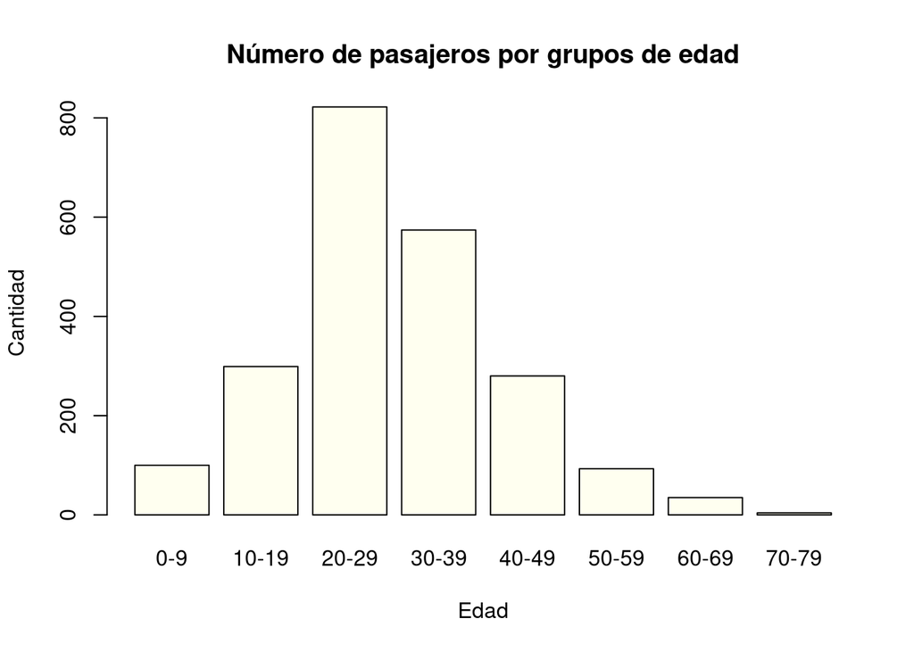

```r
plot(totalData$segmento_edad,main="Número de pasajeros por grupos de edad",xlab="Edad", ylab="Cantidad",col = "ivory")
```

Ahora repetimos por el proceso pero solo por el subconjunto de tripulación filtrado antes.

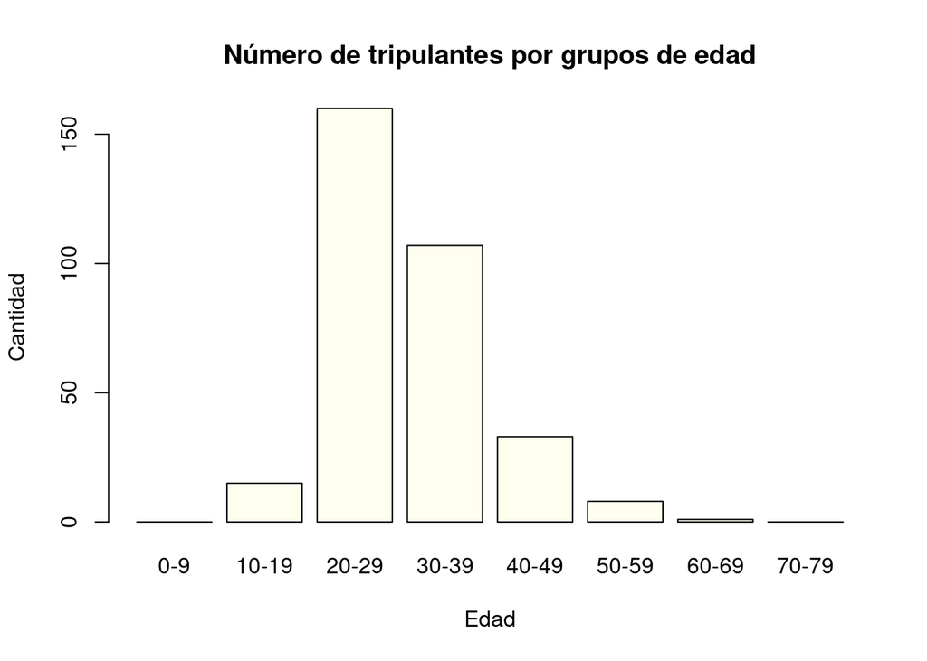

```r
totalData_crew["segmento_edad"] <- cut(totalData_crew$age, breaks = c(0,10,20,30,40,50,60,70,100), labels = c("0-9", "10-19", "20-29", "30-39","40-49","50-59","60-69","70-79"))
plot(totalData_crew$segmento_edad,main="Número de tripulantes por grupos de edad",xlab="Edad", ylab="Cantidad",col = "ivory")
```

De la discretizaón de la edad observamos que realmente la gente que viajaba era muy joven. El segmento más grande era de 20 a 29 años. También vemos de la juventud de la tripulación.

Como alternativa a la discretización realizada discretizaremos ahora edad con kmeans.

```r
# https://cran.r-project.org/web/packages/arules/index.html
if (!require('arules')) install.packages('arules'); library('arules')
set.seed(2)
table(discretize(totalData$age, "cluster" ))
```

[output not shown]

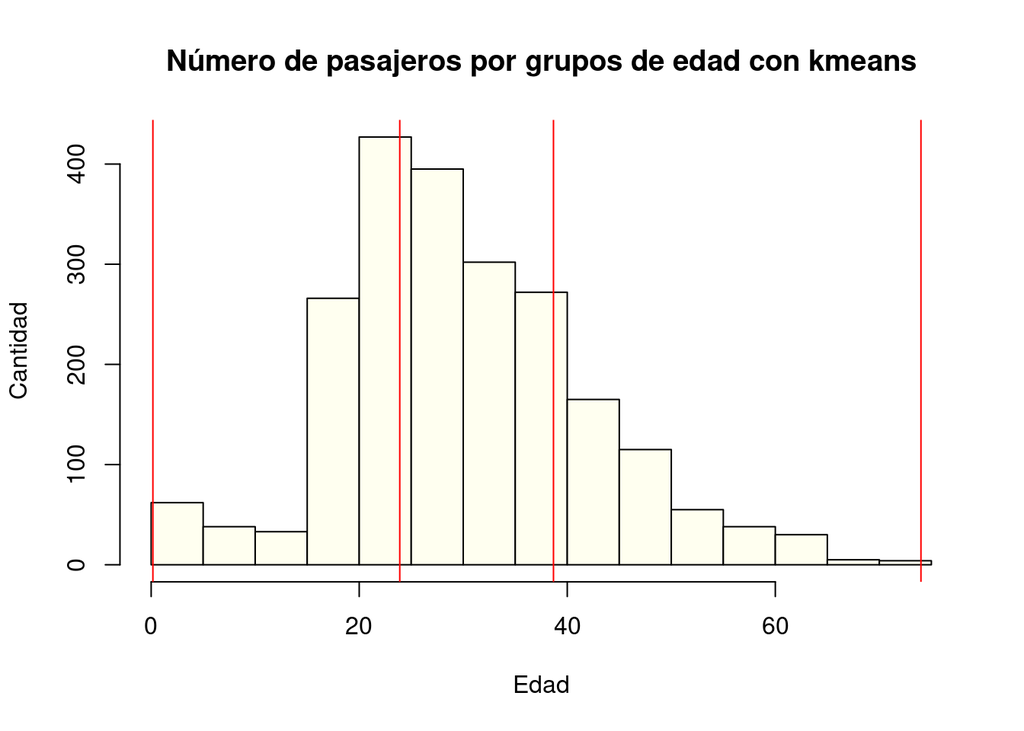

```r
hist(totalData$age, main="Número de pasajeros por grupos de edad con kmeans",xlab="Edad", ylab="Cantidad",col = "ivory")
abline(v=discretize(totalData$age, method="cluster", onlycuts=TRUE),col="red")
```

Podemos observar que sin pasar ningún argumento y que el algoritmo escoja el conjunto de particiones se muestran tres clústeres que agrupan las edades en las franjas mencionadas. Podemos asignar el propio clúster como una variable más al dataset para trabajar después.

```r
totalData$edad_KM <- (discretize(totalData$age, "cluster" ))
head(totalData)
```

```
##                             name gender age class embarked       country
## 1            Abbing, Mr. Anthony   male  42   3rd        S United States
## 2      Abbott, Mr. Eugene Joseph   male  13   3rd        S United States
## 3    Abbott, Mr. Rossmore Edward   male  16   3rd        S United States
## 4 Abbott, Mrs. Rhoda Mary 'Rosa' female  39   3rd        S       England
## 5    Abelseth, Miss. Karen Marie female  16   3rd        S        Norway
## 6  Abelseth, Mr. Olaus Jørgensen   male  25   3rd        S United States
##   ticketno  fare sibsp parch survived segmento_edad      edad_KM
## 1     5547  7.11     0     0       no         40-49    [38.7,74]
## 2     2673 20.05     0     2       no         10-19 [0.167,23.9)
## 3     2673 20.05     1     1       no         10-19 [0.167,23.9)
## 4     2673 20.05     1     1      yes         30-39    [38.7,74]
## 5   348125  7.13     0     0      yes         10-19 [0.167,23.9)
## 6   348122  7.13     0     0      yes         20-29  [23.9,38.7)
```

Ahora normalizaremos la edad de los pasajeros por el máximo añadiendo un nuevo valor a los datos que contendrá el valor.

```r
totalData$age_NM <- (totalData$age/max(totalData[,"age"]))
head(totalData$age_NM)
```

```
## [1] 0.5675676 0.1756757 0.2162162 0.5270270 0.2162162 0.3378378
```

Supongamos que queremos normalizar por la diferencia para ubicar entre 0 y 1 la variable edad del pasajero dado que el algoritmo de minería que utilizaremos así lo requiere. observamos la distribución de la variable original y las tres generadas

```r
totalData$age_ND = (totalData$age-min(totalData$age))/(max(totalData$age)-min(totalData$age))

max(totalData$age)
```

```
## [1] 74
```

```r
min(totalData$age)
```

```
## [1] 0.1666667
```

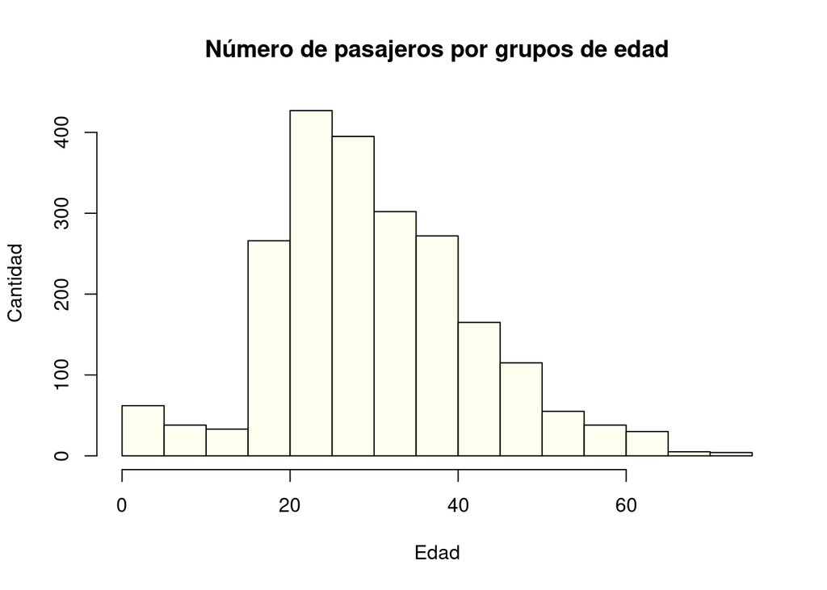

```r
hist(totalData$age,xlab="Edad", col="ivory",ylab="Cantidad", main="Número de pasajeros por grupos de edad")
```

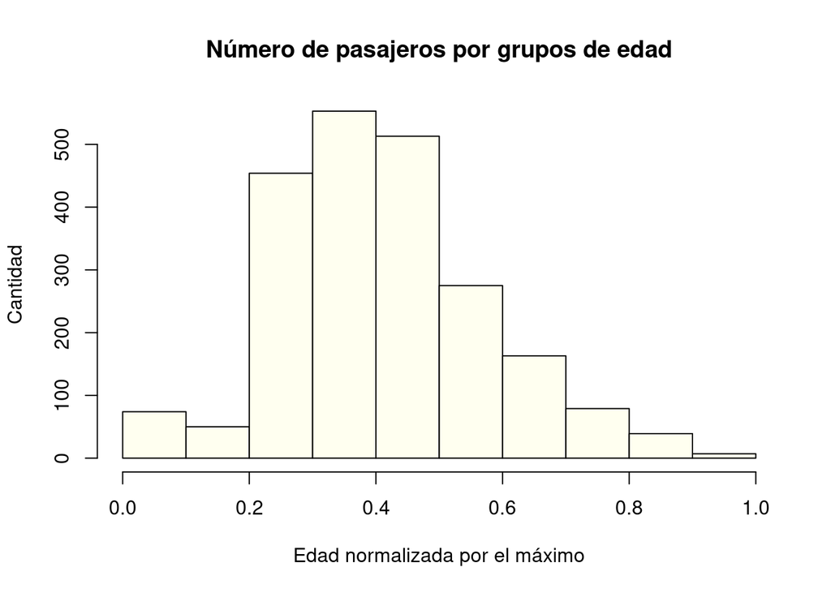

```r
hist(totalData$age_NM,xlab="Edad normalizada por el máximo", ylab="Cantidad",col="ivory", main="Número de pasajeros por grupos de edad")
```

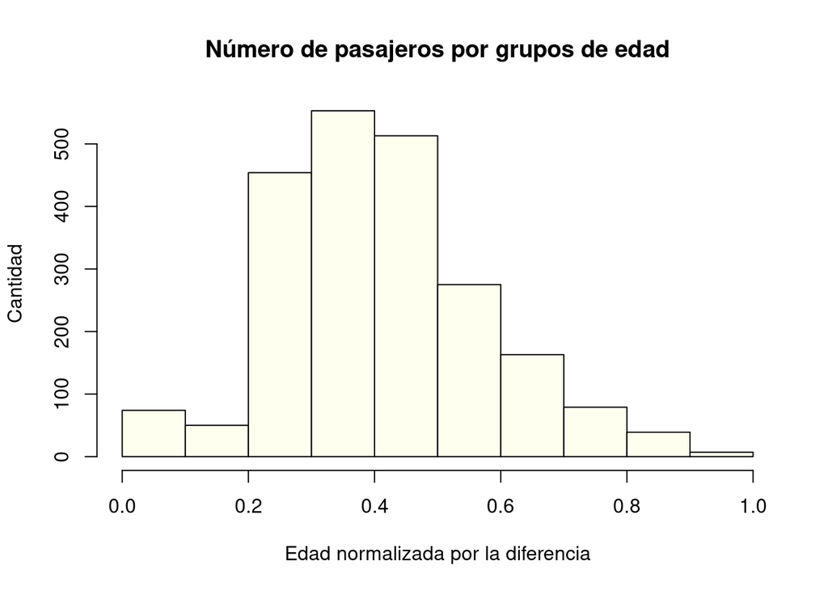

```r
hist(totalData$age_ND,xlab="Edad normalizada por la diferencia",ylab="Cantidad", col="ivory", main="Número de pasajeros por grupos de edad")
```

## 2.3 Procesos de análisis visuales del juego de datos

Nos proponemos analizar las relaciones entre las diferentes variables del juego de datos para ver si se relacionan y como.

Visualizamos la relación entre las variables “gender” y “survived”:

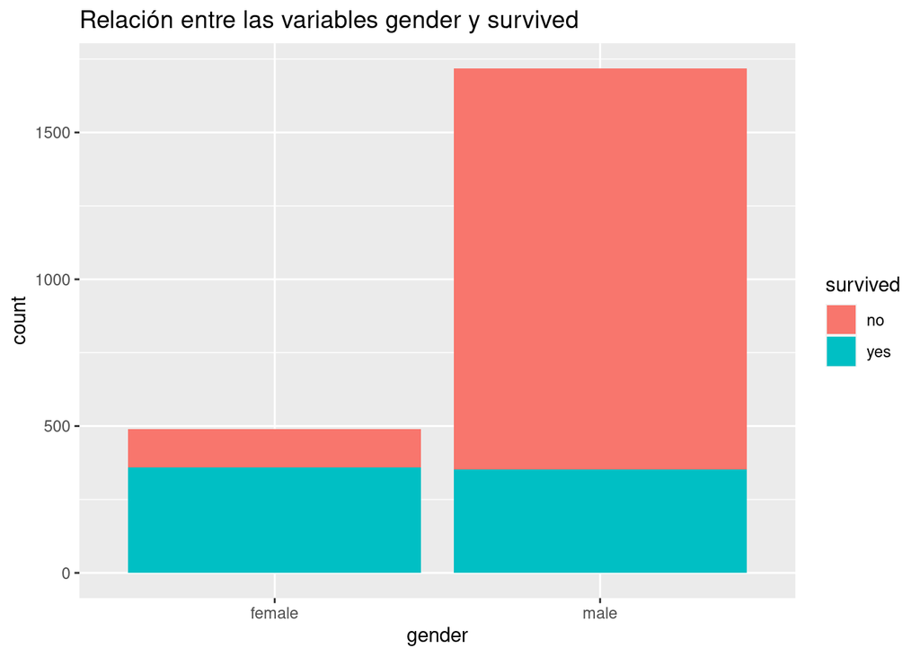

```r
ggplot(data=totalData[1:filas,],aes(x=gender,fill=survived))+geom_bar()+ggtitle("Relación entre las variables gender y survived")
```

Otro punto de vista. Survived como función de Embarked:

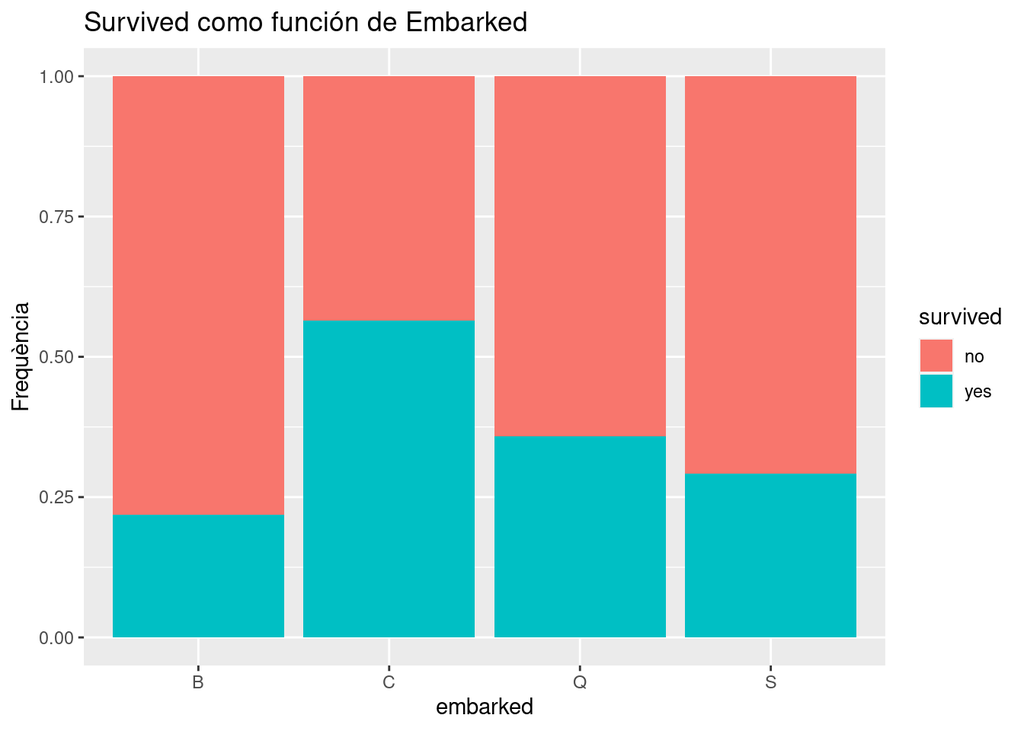

```r
ggplot(data=totalData[1:filas,],aes(x=embarked,fill=survived))+geom_bar(position="fill")+ylab("Frequència")+ggtitle("Survived como función de Embarked")
```

En la primera gráfica podemos observar fácilmente la cantidad de mujeres que viajaban respecto hombres y observar los que no sobrevivieron. Numéricamente el número de hombres y mujeres supervivientes es similar.

En la segunda gráfica de forma porcentual observamos los puertos de embarque y los porcentajes de supervivencia en función del puerto. Se podría trabajar el puerto C (Cherburgo) para ver de explicar la diferencia en los datos. Quizás porcentualmente embarcaron más mujeres o niños… ¿O gente de primera clase?

Obtenemos ahora una matriz de porcentajes de frecuencia. Vemos, por ejemplo que la probabilidad de sobrevivir si se embarcó en “C” es de un 56.45%

```r
t<-table(totalData[1:filas,]$embarked,totalData[1:filas,]$survived)
for (i in 1:dim(t)[1]){
    t[i,]<-t[i,]/sum(t[i,])*100
}
t
```

```
##
##           no      yes
##   B 78.17259 21.82741
##   C 43.54244 56.45756
##   Q 64.22764 35.77236
##   S 70.85396 29.14604
```

Veamos ahora como en un mismo gráfico de frecuencias podemos trabajar con 3 variables: Embarked, Survived y class.

Mostramos el gráfico de embarcados por Pclass:

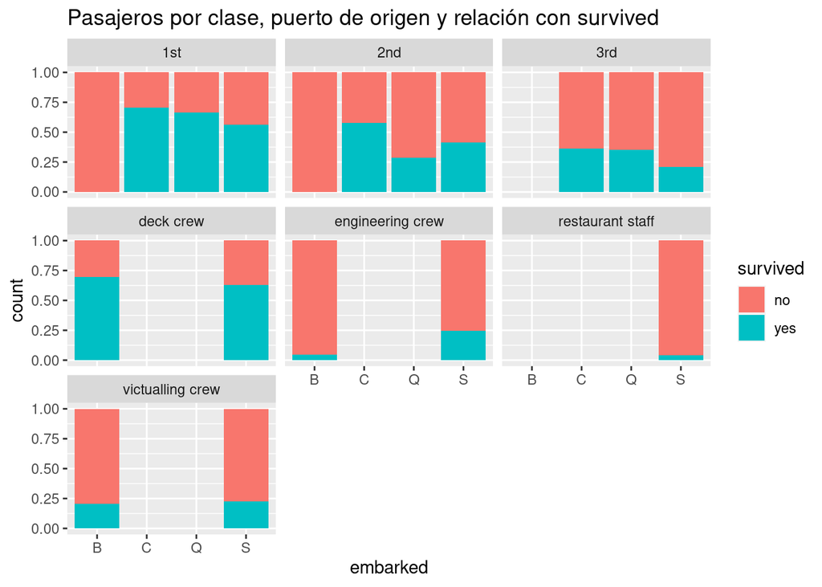

```r
ggplot(data = totalData[1:filas,],aes(x=embarked,fill=survived))+geom_bar(position="fill")+facet_wrap(~class)+ggtitle("Pasajeros por clase, puerto de origen y relación con survived")
```

Aquí ya podemos extraer mucha información. Como propuesta de mejora se podría hacer un gráfico similar trabajando solo la clase. Habría que unificar toda la tripulación a una única categoría.

Comparamos ahora dos gráficos de frecuencias: Survived-SibSp y Survived-Parch

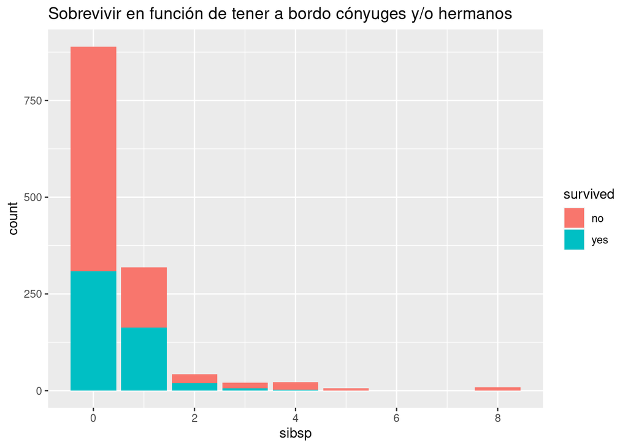

```r
ggplot(data = totalData[1:filas,],aes(x=sibsp,fill=survived))+geom_bar()+ggtitle("Sobrevivir en función de tener a bordo cónyuges y/o hermanos")
```

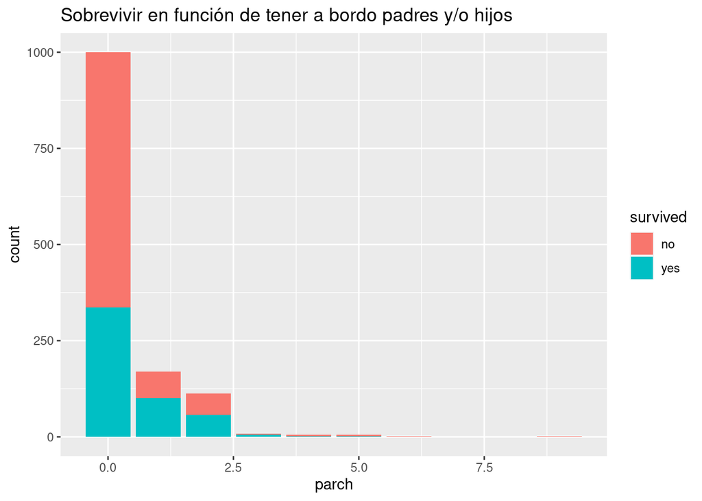

```r
ggplot(data = totalData[1:filas,],aes(x=parch,fill=survived))+geom_bar()+ggtitle("Sobrevivir en función de tener a bordo padres y/o hijos")
```

Vemos como la forma de estos dos gráficos es similar. Este hecho nos puede indicar presencia de correlaciones altas. Hecho previsible en función de la descripción de las variables.

Veamos un ejemplo de construcción de una variable nueva: Tamaño de familia

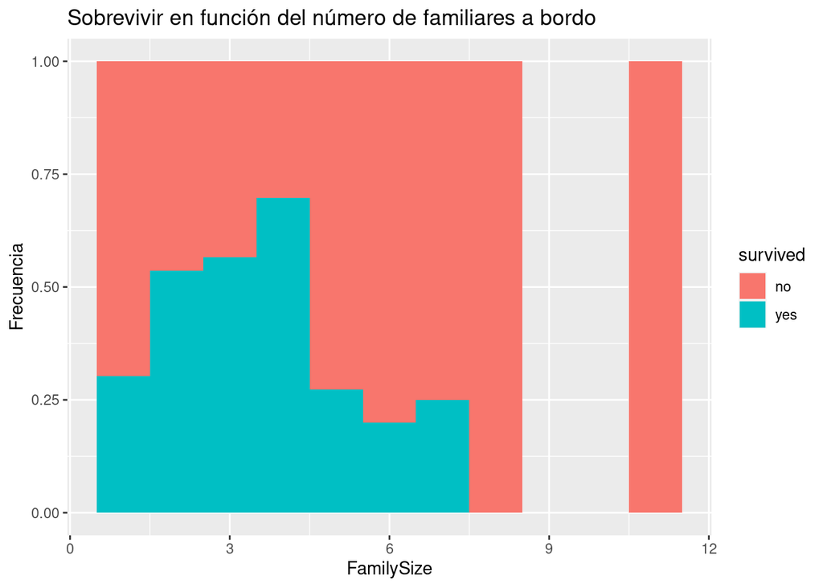

```r
totalData$FamilySize <- totalData$sibsp + totalData$parch +1;
totalData1<-totalData[1:filas,]
ggplot(data = totalData1[!is.na(totalData[1:filas,]$FamilySize),],aes(x=FamilySize,fill=survived))+geom_histogram(binwidth =1,position="fill")+ylab("Frecuencia")+ggtitle("Sobrevivir en función del número de familiares a bordo")
```

Veamos ahora dos gráficos que nos comparan los atributos Age y Survived. Observamos como el parámetro position=“fill” nos da la proporción acumulada de un atributo dentro de otro

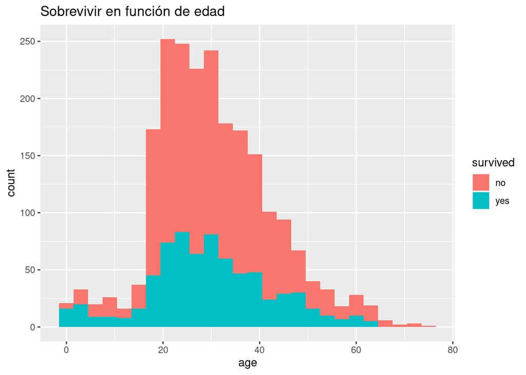

```r
ggplot(data = totalData1[!(is.na(totalData[1:filas,]$age)),],aes(x=age,fill=survived))+geom_histogram(binwidth =3)+ggtitle("Sobrevivir en función de edad")
```

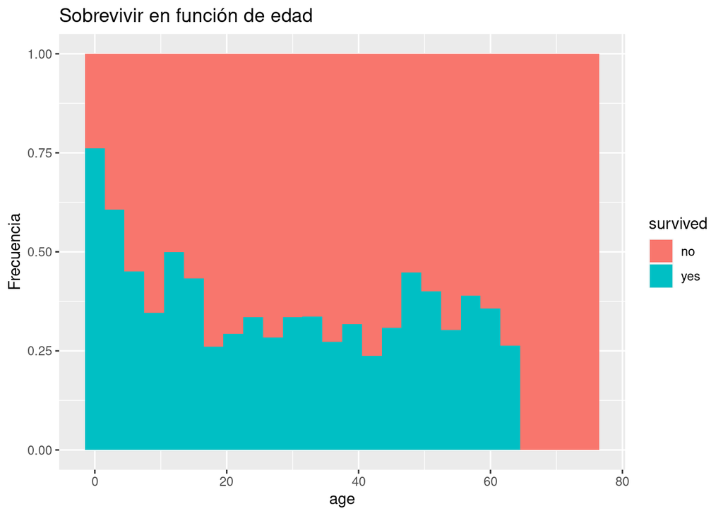

```r
ggplot(data = totalData1[!is.na(totalData[1:filas,]$age),],aes(x=age,fill=survived))+geom_histogram(binwidth = 3,position="fill")+ylab("Frecuencia")+ggtitle("Sobrevivir en función de edad")
```

Observamos como el parámetro position=“hijo” nos da la proporción acumulada de un atributo dentro de otro. Parece que los niños tuvieron más posibilidad de salvarse.

Vamos a probar si hay una correlación entre la edad del pasajero y el que pagó por el viaje

```r
# https://cran.r-project.org/web/packages/tidyverse/index.html
if (!require('tidyverse')) install.packages('tidyverse'); library('tidyverse')
cor.test(x = totalData$age, y = totalData$fare, method = "pearson")
```

```
##
##  Pearson's product-moment correlation
##
## data:  totalData$age and totalData$fare
## t = 6.7199, df = 1289, p-value = 2.722e-11
## alternative hypothesis: true correlation is not equal to 0
## 95 percent confidence interval:
##  0.1307297 0.2361631
## sample estimates:
##       cor
## 0.1839756
```

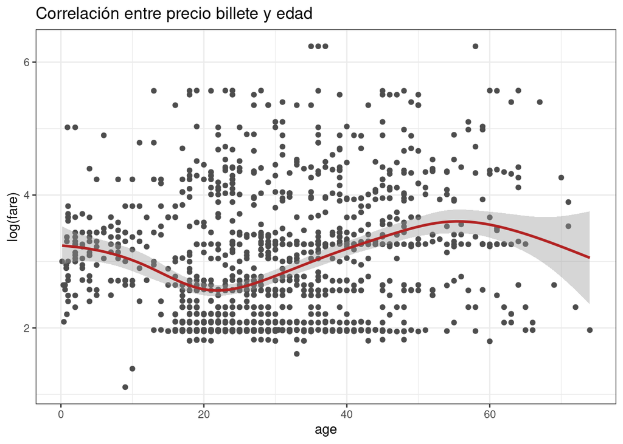

```r
ggplot(data = totalData, aes(x = age, y = log(fare))) + geom_point(color = "gray30") + geom_smooth(color = "firebrick") + theme_bw() +ggtitle("Correlación entre precio billete y edad")
```

## 2.4 Conclusiones finales

Los datos tienen una calidad correcta y están mayoritariamente bien informados. Disponen de una variable de clase “survived” que los hace aptos para un clasificador. A parte de la mayor supervivencia de mujeres y niños y de pasajeros de primera clase podemos observar la juventud de los pasajeros y la tripulación. Se observa también una gran cantidad de personas que viajaban en familia.

# 3 Ejercicios

## 3.1 Ejercicio 1:

Propon un proyecto completo de minería de datos. La organización de la respuesta tiene que coincidir con las fases típicas del ciclo de vida de un proyecto de minería de datos. *No hay que hacer las tareas de cada fase*. Para cada fase indica cuál es el objetivo de la fase y el producto que se obtendrá. Utiliza ejemplos de qué y como podrían ser las tareas. Si hay alguna característica que hace diferente el ciclo de vida de un proyecto de minería respecto a otros proyectos indícalo.

### 3.1.1 Respuesta:

En primer lugar, podemos entender la Minería de datos como un proceso que se centra en descubrir patrones en conjuntos de datos de gran volumen con técnicas y tecnologías que permiten explorar grandes bases de datos, a veces de manera automática y otras veces semiautomática, con el principal objetivo de encontrar modelos de repetición, tendencias y reglas que expliquen el comportamiento de esos datos en un determinado contexto. Dicho proceso de exploración de datos, cuenta con fases que siguen un orden metodológico, las cuales nos ayudan extraer conocimiento significativo. Este proceso general sigue las siguientes fases:

- Obtención de datos.
- Tratamiento.
- Ejecución del modelo.
- Evaluación y selección del modelo ganador.
- Puesta en producción del modelo.

Ahora bien, en lo que respecta a **implementar un proyecto de minería de datos**, podemos seguir la metodología CRISP-DM (CRoss Industry Standard Process for Data Mining) que se basa en seis fases: análisis del negocio, captura de datos, tratamiento de datos, modelado, evaluación e implantación. A continuación, detallamos una propuesta de proyecto con las 6 fases antes mencionadas:

**Nombre del proyecto:**

Análisis del Patrón de repetición de compra de clientes de una empresa industrial.

**Contexto empresarial:**

La empresa industrial Olivo fabrica contenedores isotérmicos y cuenta con diferentes clientes a nivel Europeo. Tiene clasificados a los clientes por País, Región, tipo de contenedores que compra e información histórica de facturación. Asimismo, tiene varios competidores que fabrican productos similares. En ese sentido necesita elaborar un modelo que le permita predecir patrones de repetición de compra de sus clientes y poder fidelizarlos con promociones personalizadas con el fin de mantener su cartera de clientes y maximizar sus beneficios.

Para ello, ha encargado a una agencia especializada en el tema un proyecto de Minería de Datos. Dicha agencia está siguiendo los lineamientos de la metodología CRISP-DM. Las tareas que ha determinado para cada fase y sus correspondientes productos derivados se mencionan a continuación:

1. Análisis de negocio:

Objetivo: El objetivo en esta fase se centra en los objetivos empresariales y los requerimientos del proyecto. Se trata de entender el negocio y el problema que se quiere resolver. Es una fase muy importante que debe ser aprovechada para establecer los lineamientos base del proyecto. En el caso de Olivo, sería hacer un modelo predictivo de repetición de compra.

Producto: El producto que se obtiene en esta fase es un plan detallado del proyecto donde se especifiquen los antecedentes de la empresa, los objetivos empresariales, los criterios de éxito empresarial, se haga un inventario de recursos, se establezcan los requerimientos, supuestos y limitaciones del proyecto, los riesgos y el plan de contingencia, se elabore una Terminología para el proyecto, los costes y beneficios del proyecto, los objetivos del proyecto de minería de datos, un plan del proyecto y una evaluación inicial de herramientas y técnicas.

Ejemplos de Tareas:

- Un objetivo a establecer es mantener los clientes actuales de Olivo siendo capacez de predecir en qué momento los clientes son propensos a comprar otro producto similar.
- Un ejemplo de criterio de éxito empresarial podría ser fijar el nivel de fuga de clientes en 1% mensual como máximo. Además, asegurar una repetición de compra para el año siguiente.
- Otro ejemplo en esta etapa sería listar los recursos disponibles en términos de personal, datos y software.
- También es típico en esta fase hacer una lista de las limitaciones a las que se enfrenta el proyecto. Establecer los supuestos y los requerimientos del proyecto.
- Hacer una lista de los riesgos y tener un plan de contingencia.
- Realizar un estudio de costes y beneficios del proyecto en términos monetarios basados en el rendimiento comercial.
- Una tarea crucial sería determinar los objetivos de la minería de datos en conjunción con el criterio de éxito. Por ejemplo, predecir cuántos contenedores comprará determinado cliente dado la información de la facturación de los 5 años anteriores, el precio del producto y la información demográfica.
- Otra tarea podría ser producir un plan detallado de las técnicas y herramientas a utilizar y los disitintos pasos a seguir durante el proyecto.
2. Captura de datos:

Objetivo: Su objetivo principal es el de la identificación, recogida y análisis del conjunto de datos que nos ayudarán a resolver el problema propuesto y alcanzar los objetivos empresariales.

Producto: El producto que se obtiene en esta fase es un reporte con la descripción del conjunto de datos a investigar.

Ejemplos de tareas:

- En este etapa por ejemplo se debe especificar la herramiemta elegida para dicha actividad.
- Se examinan las propiedades de los datos “en crudo” y se informa de los resultados.
- Otra tarea sería explorar la distribución de las variables. Se utiliza la visualización, las consultas, las relaciones entre pares de atributos, los resultados de agregaciones simples, las propiedades de las sub-poblaciones y un análisis estadístico básico.
- También se realizan verificaciones sobre la calidad de los datos, es decir, si contienen errores o si existen valores nulos o vacíos.
3. Tratamiento:

Objetivo: Se centra en la preparación del conjunto o los conjuntos finales de datos para utilizarlos en la fase de modelado. Es decir, cubre todas las actividades necesarias para construir el conjunto de datos final (datos que se incorporarán a las herramientas de modelado) a partir de los datos brutos iniciales. Es probable que las tareas de preparación de datos se realicen varias veces y no en cualquier orden prescrito.

Producto: El producto que se deriva de esta fase es un informe de los pasos del preprocesamiento realizado para producir los datos que serán explotados.

Ejemplos de tareas:

- Se realizan tareas de selección de atributos y registros, limpieza de datos, derivación de atributos nuevos a partir de los presentes.
- Otra tarea sería la integración de datos, es decir, la combinación de tablas y registros.
- Se realizan tareas de cambios en los formatos de los atributos para prepararlos de una manera más eficiente cuando sean utilizados por las herramientas de modelado.
- La tarea principal sería producir un dataset que esté listo para se utilizado en las herramientas de modelado. Todo ello se puede conseguir de las bases de datos de Olivo.
4. Modelado:

Objetivo: Su objetivo es el de construir y evaluar varios modelos basados en diferentes técnicas de modelado.

Producto: El producto generado en esta fase es un informe con los supuestos establecidos en el modelado, el diseño de la prueba, la descripción de los modelos y su evaluación respectiva.

Ejemplos de tareas:

- Una tarea esencial es la de elegir la técnica de modelado. Por ejemplo, árboles de decisión, redes neuronales, etc. En el caso de Olivo, sería un problema de clasificación y se pueden utilizar modelos tipo: Análisis de regresión, Árbol de regresión, Redes neuronales, K nearest neighbor, entre otros algoritmos.
- Otra tarea es la de diseñar la prueba. Es típico dividir la muestra en conjuntos de “test” y “train”.
- Construir el modelo ejecutando la herramienta de modelado con el conjunto de datos preprocesado para crear uno o más modelos.
- Otra tarea es la de evaluar los modelos y hacer un ranking de los modelos utilizados donde se considera también los objetivos de la empresa y el criterio de éxito. Esta tarea de evaluación se hace específicamente para los modelos utilizados.
5. Evaluación:

Objetivo: Su objetivo es el de observar los resultados y determinar qué algoritmo responde mejor a la cuestión planteada. Mientras que la tarea de evaluar modelo de la fase de modelado se centra en la evaluación del modelo técnico, la fase de evaluación analiza de manera más amplia qué modelo se adapta mejor al negocio y qué hacer a continuación.

Producto: Es un reporte que compara los resultados de la minería de datos con los criterios empresariales de éxito. Asimismo, se incluye una revisión del proyecto y una lista con los siguientes pasos a seguir.

Ejemplos de tareas:

- La tarea principal es la de evaluar de manera profunda el proyecto en todas sus fases. Además, ésta evaluación debe ir en concordancia con los ojetivos empresariales y el critería de éxito.
- Otra tarea sería la de evaluar la precisión y generalización del modelo.
- En el caso que el modelo sea deficiente se realizarán tareas para determinar la causa de ello.
- Se realiza una revisión de la totalidad del proceso para establecer si se construyó correctamente el modelo y si los atributos utilizados fueron solo los permitidos y que estarán disponibles de cara al futuro.
- Otra tarea es la de determinar los pasos a seguir, es decir, si se continua con la implementación del proyecto o se inician un mayor número de iteraciones o si se establecen nuevos proyectos de minería.
6. Implantación:

Objetivo: Es la fase final y su objetivo es el acceso de los clientes a los resultados. En otras palabras, un modelo no es particularmente útil a menos que el cliente pueda acceder a sus resultados.

Producto: Se realiza un informe con el plan de implementación, un plan de monitoreo y mantenimiento y el reporte final del proyecto.

Ejemplos de tareas:

- Se realizan tareas de implementación dados los resultados de la fase de evaluación y se establece una estrategia acorde.
- Se llevan a cabo tareas de mantenimiento y monitoreo si el resultado del proyecto se convierte en parte del día a día de la empresa.
- Otra tarea de esta fase es la de generar un reporte final y una presentación sintetizada de los resultados del proyecto de minería.
- Se llevan a cabo revisiones de qué es lo que se hizo mal, qué salió bien y qué salió mal y las cosas necesarias para mejorar el proyecto. En otras plabras, se resume y se documenta la experiencia ganada para futuros proyectos.

Por otro lado, si hay algo que diferencia a los proyectos de Minería de datos es su capacidad bidireccional y transversal, no sigue un patrón lineal, sino que se retroalimenta en cada fase, se ajusta y se mira hacia atrás en busca de mejoras constantes.

Finalmente, hay que diferenciar la Minería de Datos con proyectos de BI (business intelligence) y Big Data. Son tres herramientas que coesxisten y que se utilizan dentro de las organizaciones pero la diferencia radica en el volumen de datos, el propósito de cada herramienta y el resultado.

Asimismo, debemos tener claro qué no es un proyecto de Minería de datos. Por ejemplo, hacer una encuesta aislada que nos sirva simplemente para establecer la propensión de compra de nuestros clientes y enviarles mails con ofertas, no es sinónimo de un proyecto de Minería de datos, es más bien, una campaña de marketing.  
En otras palabras, la Minería de datos implica un proceso, un ciclo con distintas fases.

## 3.2 Ejercicio 2:

A partir del juego de datos disponible en el siguiente enlace https://www.kaggle.com/rdoume/beerreviews , realiza las tareas previas a la generación de un modelo de minería de datos explicadas en los módulos “El proceso de minería de datos” y “Preprocesado de los datos y gestión de características”. Puedes utilizar de referencia el ejemplo del Titánic.

### 3.2.1 Descripción de los datos:

El dataset alcanzado se refiere a las opiniones o calificaciones de cervezas de distintos amantes de las mismas. Cuenta con 12 variables dependientes que influyen en la formación de dicha opinión.

#### 3.2.1.1 Variable dependiente:

La variable dependiente en este caso es la calificación general (review_overall) que se tiene de las distintas cervezas del dataset. Es decir, la calificación total de la cerveza. El detalle de la variable es el siguiente:

**review_overall** numérico, calificación total de la cerveza.

#### 3.2.1.2 Variables independientes:

Para formar la opinión y poder calificar una cerveza, el juego de datos cuenta con 12 variables dependientes.

Revisamos la descripción de las 13 variables contenidas en el fichero:

**brewery_id**  
numérico, se trata del número de identificación de la cervecería.

**brewery_name**  
carácter, se refiere al nombre de la cervecería.

**review_time**  
valor numérico de la fecha, formato “epoch”.

**review_aroma**  
numérico, calificación del aroma de la cerveza.

**review_appearance**  
numérico, calificación de la apariencia la cerveza.

**review_profilename**  
carácter, nombre de perfil del que realizó la calificación o valoración.

**beer_style**  
carácter, tipo de cerveza específico.

**review_palate**  
numérico, calificación de la cerveza en el paladar.

**review_taste**  
numérico, calificación del gusto y sabor de la cerveza.

**beer_name**  
carácter, nombre de la cerveza.

**beer_abv**  
numérico, grado de alcohol en la cerveza.

**beer_beerid**  
numérico, número de identificación de la cerveza.

#### 3.2.1.3 Lectura de los datos:

Procedemos a la lectura de los datos dentro del entorno de trabajo de RStudio:

```r
df <- read.csv('beer_reviews.csv', stringsAsFactors = FALSE)
filas=dim(df)[1]
```

Verificamos la estructura del dataset:

```r
str(df)
```

```
## 'data.frame':    1586614 obs. of  13 variables:
##  $ brewery_id        : int  10325 10325 10325 10325 1075 1075 1075 1075 1075 1075 ...
##  $ brewery_name      : chr  "Vecchio Birraio" "Vecchio Birraio" "Vecchio Birraio" "Vecchio Birraio" ...
##  $ review_time       : int  1234817823 1235915097 1235916604 1234725145 1293735206 1325524659 1318991115 1306276018 1290454503 1285632924 ...
##  $ review_overall    : num  1.5 3 3 3 4 3 3.5 3 4 4.5 ...
##  $ review_aroma      : num  2 2.5 2.5 3 4.5 3.5 3.5 2.5 3 3.5 ...
##  $ review_appearance : num  2.5 3 3 3.5 4 3.5 3.5 3.5 3.5 5 ...
##  $ review_profilename: chr  "stcules" "stcules" "stcules" "stcules" ...
##  $ beer_style        : chr  "Hefeweizen" "English Strong Ale" "Foreign / Export Stout" "German Pilsener" ...
##  $ review_palate     : num  1.5 3 3 2.5 4 3 4 2 3.5 4 ...
##  $ review_taste      : num  1.5 3 3 3 4.5 3.5 4 3.5 4 4 ...
##  $ beer_name         : chr  "Sausa Weizen" "Red Moon" "Black Horse Black Beer" "Sausa Pils" ...
##  $ beer_abv          : num  5 6.2 6.5 5 7.7 4.7 4.7 4.7 4.7 4.7 ...
##  $ beer_beerid       : int  47986 48213 48215 47969 64883 52159 52159 52159 52159 52159 ...
```

Vemos que tenemos 1’586,614 registros que se corresponden a las calificaciones sobre cervezas y 13 variables que las caracterizan.

### 3.2.2 Estadísticas básicas:

Posteriormente, observamos las estadísticas básicas del dataset:

```r
summary(df)
```

```
##    brewery_id    brewery_name        review_time        review_overall
##  Min.   :    1   Length:1586614     Min.   :8.407e+08   Min.   :0.000
##  1st Qu.:  143   Class :character   1st Qu.:1.173e+09   1st Qu.:3.500
##  Median :  429   Mode  :character   Median :1.239e+09   Median :4.000
##  Mean   : 3130                      Mean   :1.224e+09   Mean   :3.816
##  3rd Qu.: 2372                      3rd Qu.:1.289e+09   3rd Qu.:4.500
##  Max.   :28003                      Max.   :1.326e+09   Max.   :5.000
##
##   review_aroma   review_appearance review_profilename  beer_style
##  Min.   :1.000   Min.   :0.000     Length:1586614     Length:1586614
##  1st Qu.:3.500   1st Qu.:3.500     Class :character   Class :character
##  Median :4.000   Median :4.000     Mode  :character   Mode  :character
##  Mean   :3.736   Mean   :3.842
##  3rd Qu.:4.000   3rd Qu.:4.000
##  Max.   :5.000   Max.   :5.000
##
##  review_palate    review_taste    beer_name            beer_abv
##  Min.   :1.000   Min.   :1.000   Length:1586614     Min.   : 0.01
##  1st Qu.:3.500   1st Qu.:3.500   Class :character   1st Qu.: 5.20
##  Median :4.000   Median :4.000   Mode  :character   Median : 6.50
##  Mean   :3.744   Mean   :3.793                      Mean   : 7.04
##  3rd Qu.:4.000   3rd Qu.:4.500                      3rd Qu.: 8.50
##  Max.   :5.000   Max.   :5.000                      Max.   :57.70
##                                                     NA's   :67785
##   beer_beerid
##  Min.   :    3
##  1st Qu.: 1717
##  Median :13906
##  Mean   :21713
##  3rd Qu.:39441
##  Max.   :77317
##
```

Contamos los valores únicos por Cervecería:

```r
reviews_brewery_name_unique_length <- length(unique(df$brewery_name))
reviews_brewery_name_unique_length
```

```
## [1] 5743
```

Contamos los valores únicos por cerveza:

```r
reviews_beer_name_unique_length <- length(unique(df$beer_name))
reviews_beer_name_unique_length
```

```
## [1] 56857
```

En resumen, el dataset contiene alrededor de 1.6 millones de opiniones de 60 mil cervezas pertenecientes aproximadamente a 6 mil cervecerías.

### 3.2.3 Preprocesamiento de datos:

#### 3.2.3.1 Transformación de tipos de datos:

Analizamos los diferentes tipos de datos para decidir si se tienen que transformar:

```r
sapply(df, class)
```

```
##         brewery_id       brewery_name        review_time     review_overall
##          "integer"        "character"          "integer"          "numeric"
##       review_aroma  review_appearance review_profilename         beer_style
##          "numeric"          "numeric"        "character"        "character"
##      review_palate       review_taste          beer_name           beer_abv
##          "numeric"          "numeric"        "character"          "numeric"
##        beer_beerid
##          "integer"
```

Tenemos variables que son categóricas y hay que transformar a “factor” porque tienen el tipo “character” en su lugar:

```r
df[sapply(df, is.character)] <- lapply(df[sapply(df, is.character)], as.factor)
```

Verificamos el cambio:

```r
sapply(df, class)
```

```
##         brewery_id       brewery_name        review_time     review_overall
##          "integer"           "factor"          "integer"          "numeric"
##       review_aroma  review_appearance review_profilename         beer_style
##          "numeric"          "numeric"           "factor"           "factor"
##      review_palate       review_taste          beer_name           beer_abv
##          "numeric"          "numeric"           "factor"          "numeric"
##        beer_beerid
##          "integer"
```

Así bien, éstas variables categóricas se han convertido en “factors” dentro del “dataframe”.

Por otro lado, la variable “review_time” está en formato integer (epoch) debemos transformarlo para una mayor claridad:

```r
df[ , "review_time"] <- as.POSIXct(df[, "review_time"], origin = "1970-01-01", tz = "CTE")
```

```r
df[ , "review_time"] <- as.Date(df[ , "review_time"])
```

Comprobamos “review_time”:

```r
summary(df$review_time)
```

```
##         Min.      1st Qu.       Median         Mean      3rd Qu.         Max.
## "1996-08-22" "2007-03-06" "2009-04-08" "2008-10-15" "2010-10-31" "2012-01-11"
```

El resultado es un mix de 4 variables categóricas y el resto continuas.

#### 3.2.3.2 Tratamiento de valores vacíos:

Según la comprobación anterior observamos la mayoría de valores “NA” en la variable “beer_abv”. Asimismo, comprobamos los valores vacíos del dataframe:

```r
colSums(is.na(df))
```

```
##         brewery_id       brewery_name        review_time     review_overall
##                  0                  0                  0                  0
##       review_aroma  review_appearance review_profilename         beer_style
##                  0                  0                  0                  0
##      review_palate       review_taste          beer_name           beer_abv
##                  0                  0                  0              67785
##        beer_beerid
##                  0
```

Otra forma de encontrar qué variables tienen atributos nulos es la siguiente:

```r
# Atributos con valores vacíos
colSums(df=="")
```

```
##         brewery_id       brewery_name        review_time     review_overall
##                  0                 15                 NA                  0
##       review_aroma  review_appearance review_profilename         beer_style
##                  0                  0                348                  0
##      review_palate       review_taste          beer_name           beer_abv
##                  0                  0                  0                 NA
##        beer_beerid
##                  0
```

Como antes mencionado, observamos que los valores nulos se concentran en la variable “beer_abv”. Determinamos su porcentaje sobre el total del dataset:

```r
reviews_null_pct <- round((sum(is.na(df$beer_abv))/filas) * 100, digits=2)
reviews_null_pct
```

```
## [1] 4.27
```

La eliminación de los valores nulos en dicha variable solo afecta al tamaño del conjunto de datos en un poco más del 4%. Para lograr un dataset “limpio”, podríamos manejar los valores que faltan imputando los datos. Sin embargo, dado que éstas variables podrían ser buenas predictoras de la calificación general de una determinada cerveza, la imputación podría conducir al sesgo en cualquier modelo predictivo.

Por lo tanto, se decide eliminar todos los casos con datos vacíos (NA), sin que exista mucha pérdida de información por su baja representatividad dentro del conjunto total de datos.

Se procede de la siguiente manera para su eliminación:

```r
reviews <- df[complete.cases(df), ]
```

Verificación del dataset:

```r
colSums(is.na(reviews))
```

```
##         brewery_id       brewery_name        review_time     review_overall
##                  0                  0                  0                  0
##       review_aroma  review_appearance review_profilename         beer_style
##                  0                  0                  0                  0
##      review_palate       review_taste          beer_name           beer_abv
##                  0                  0                  0                  0
##        beer_beerid
##                  0
```

Comprobamos nuevamente la estructura del nuevo dataset:

```r
str(reviews)
```

```
## 'data.frame':    1518829 obs. of  13 variables:
##  $ brewery_id        : int  10325 10325 10325 10325 1075 1075 1075 1075 1075 1075 ...
##  $ brewery_name      : Factor w/ 5743 levels "","'t Hofbrouwerijke",..: 5457 5457 5457 5457 1485 1485 1485 1485 1485 1485 ...
##  $ review_time       : Date, format: "2009-02-16" "2009-03-01" ...
##  $ review_overall    : num  1.5 3 3 3 4 3 3.5 3 4 4.5 ...
##  $ review_aroma      : num  2 2.5 2.5 3 4.5 3.5 3.5 2.5 3 3.5 ...
##  $ review_appearance : num  2.5 3 3 3.5 4 3.5 3.5 3.5 3.5 5 ...
##  $ review_profilename: Factor w/ 33388 levels "","0110x011",..: 28584 28584 28584 28584 16283 22916 25211 1021 18798 1744 ...
##  $ beer_style        : Factor w/ 104 levels "Altbier","American Adjunct Lager",..: 66 52 60 62 10 67 67 67 67 67 ...
##  $ review_palate     : num  1.5 3 3 2.5 4 3 4 2 3.5 4 ...
##  $ review_taste      : num  1.5 3 3 3 4.5 3.5 4 3.5 4 4 ...
##  $ beer_name         : Factor w/ 56857 levels "! (Old Ale)",..: 44543 41870 6944 44542 11364 10518 10518 10518 10518 10518 ...
##  $ beer_abv          : num  5 6.2 6.5 5 7.7 4.7 4.7 4.7 4.7 4.7 ...
##  $ beer_beerid       : int  47986 48213 48215 47969 64883 52159 52159 52159 52159 52159 ...
```

#### 3.2.3.3 Tratamiento de valores duplicados:

Establecemos como valores duplicados siguiendo el razonamiento siguiente: si un usuario ha dado su opinión sobre la misma cerveza más de una vez se mantendrá solamente la opinión de mayor rating.

```r
library(tidyverse)
rev_df <- reviews %>%
  arrange(desc(review_overall)) %>%
  distinct(across(c(review_profilename, beer_name)), .keep_all = TRUE)
```

Dimensiones del dataset sin duplicados:

```r
dim(rev_df)
```

```
## [1] 1496596      13
```

Calculamos el porcentaje de valores duplicados sobre el dataset:

```r
rev_df_dup_pct <- round((dim(reviews)[1] - dim(rev_df)[1]) / dim(reviews)[1] * 100, digits=2)
rev_df_dup_pct
```

```
## [1] 1.46
```

La eliminación de todos los valores duplicados solo afectará al tamaño del conjunto de datos en un poco más del 1.46%, es decir, dicha eliminación no es significativa.

#### 3.2.3.4 Tratamiento de valores con calificación de cero:

Observamos valores iguales a cero en las variables “review_overall” y “review_appearance”, no tiene sentido mantener dichos registros porque el rating tiene una escala de 1-5. Procedemos a su eliminación de la siguiente manera y verificamos su nueva estructura:

```r
rev <- filter(rev_df, review_overall >=1 & review_appearance >=1)
```

Se trataba de 7 registros. Observamos las dimensiones del nuevo dataset:

```r
dim(rev)
```

```
## [1] 1496589      13
```

### 3.2.4 Normalización y discretización:

#### 3.2.4.1 Normalización:

El objetivo de esta sección es determinar si debemos situar los datos sobre una escala de valores equivalentes que permita la comparación de atributos que toman valores en dominios diferentes. En otras palabras, buscaremos reducir la influencia de los atributos con valores dispares.

Para cumplir el objetivo mencionado se inspecciona el rango de valores de cada variable numérica, con el objetivo de identificar cuáles de ellas pueden ser normalizadas.

```r
# Columnas numéricas
num_cols <- unlist(lapply(rev, is.numeric))

# Subset del dataframe con las variables numéricas
data_num <- rev[ , num_cols]

# Rango de valores de cada variable
range_vars <- data.frame(sapply(data_num, range))
range_vars
```

```
##   brewery_id review_overall review_aroma review_appearance review_palate
## 1          1              1            1                 1             1
## 2      28003              5            5                 5             5
##   review_taste beer_abv beer_beerid
## 1            1     0.01           5
## 2            5    57.70       77316
```

La variable “beer_abv” es la candidata para la normalización, ya que hay pocas cervezas en el mundo con un grado de alcohol tan alto (57.70%).

Normalizamos por los mínimos o diferencia para ubicar entre 0 y 1 la variable “beer_abv” dado que los algoritmos de minería así lo requieren.

Procedemos de la siguiente forma y añadimos una nueva variable al dataframe:

```r
# Generamos una copia del dataset "limpio" para agregar variables en él normalizadas y discretizadas
rev_norm <- rev

# Normalizamos la variable
rev_norm$beer_abv_ND <- (rev$beer_abv-min(rev$beer_abv))/(max(rev$beer_abv)-min(rev$beer_abv))
head(rev_norm)
```

```
##   brewery_id            brewery_name review_time review_overall review_aroma
## 1       1075 Caldera Brewing Company  2010-08-30              5          5.0
## 2       1075 Caldera Brewing Company  2011-10-16              5          5.0
## 3       1075 Caldera Brewing Company  2011-09-03              5          4.5
## 4       1075 Caldera Brewing Company  2011-05-20              5          4.5
## 5       1075 Caldera Brewing Company  2009-07-06              5          4.0
## 6       1075 Caldera Brewing Company  2009-03-01              5          3.5
##   review_appearance review_profilename              beer_style review_palate
## 1               4.0       MadeInOregon    Herbed / Spiced Beer           4.0
## 2               3.5        optimator13               Rauchbier           3.5
## 3               4.0               Bung               Rauchbier           4.0
## 4               3.5             Deuane               Rauchbier           4.0
## 5               4.5    GratefulBeerGuy American Pale Ale (APA)           4.5
## 6               4.0            mtrentm American Pale Ale (APA)           4.0
##   review_taste           beer_name beer_abv beer_beerid beer_abv_ND
## 1            4 Caldera Ginger Beer      4.7       52159  0.08129659
## 2            5       Rauch Ür Bock      7.4       58046  0.12809846
## 3            5       Rauch Ür Bock      7.4       58046  0.12809846
## 4            5       Rauch Ür Bock      7.4       58046  0.12809846
## 5            4    Caldera Pale Ale      5.5       25414  0.09516381
## 6            5    Caldera Pale Ale      5.5       25414  0.09516381
```

Mostramos la distribución de “beer_abv”:

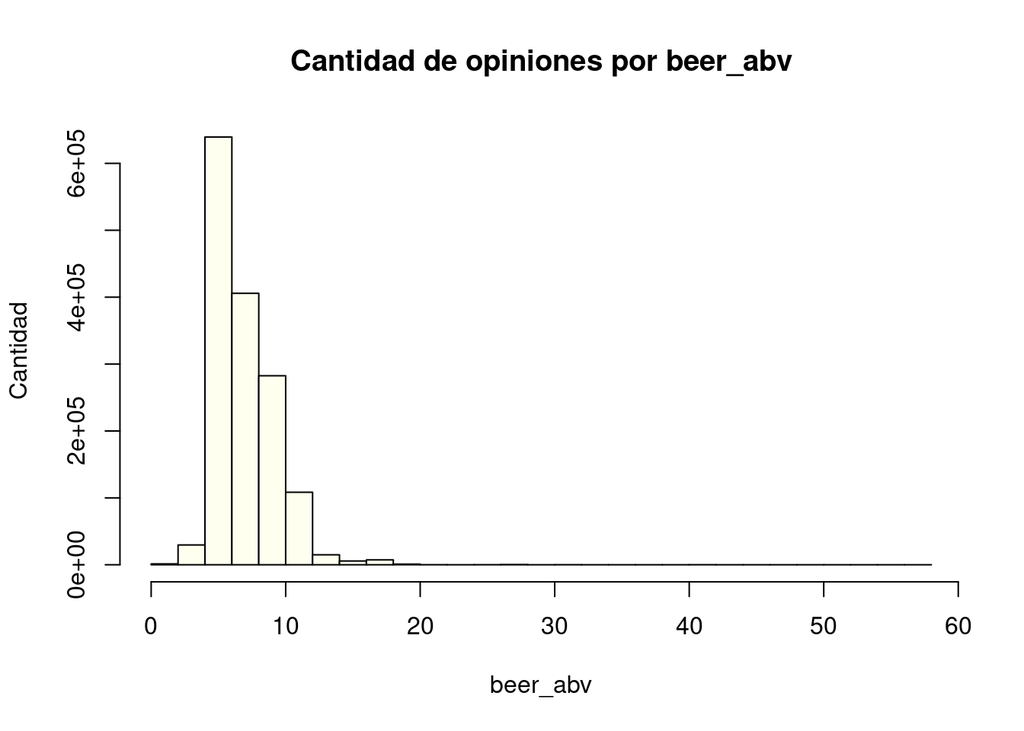

```r
hist(rev$beer_abv, xlab="beer_abv", col="ivory", ylab="Cantidad", main="Cantidad de opiniones por beer_abv")
```

Asimismo, mostramos la distribución de “beer_abv_ND”:

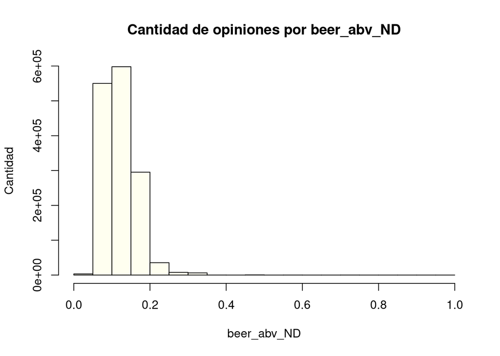

```r
hist(rev_norm$beer_abv_ND, xlab="beer_abv_ND", col="ivory", ylab="Cantidad", main="Cantidad de opiniones por beer_abv_ND")
```

Las distribuciones que se observan tienen un sesgo a la derecha, tanto en la variable sin normalizar como la normalizada. En otras palabras, la mayoría de opiniones se concentran en las cervezas con menos de 20% de “ABV” (Alcohol By Volume).

#### 3.2.4.2 Discretización:

Se puede realizar una discretización en la variable “beer_abv” para establecer un criterio y, de esa manera, dividir los valores de un atributo en dos o más conjuntos disjuntos manteniendo o mejorando las características del modelo. En ese sentido, podemos ver en la realidad alrededor del [mundo de las cervezas](http://www.differencebetween.info/difference-between-lager-beer-and-strong-beer), que es usual, en la mayoría de regiones y países, separar la intensidad del volumen de alcohol de la cerveza en base al 5% de “ABV” para obedecer la normativa sanitaria. Este etiquetado se resume en dos categorías, cervezas “light” o “strong”.

Es así que se procede de la siguiente manera para generar una nueva variable que después podría ser incluso binarizada:

```r
library(dplyr)
rev_norm_disc <- rev_norm %>%
  mutate(
    intensidad_abv = case_when(
      beer_abv < 5 ~ "light",
      TRUE         ~ "strong"
    )
  )
```

```r
head(rev_norm_disc)
```

```
##   brewery_id            brewery_name review_time review_overall review_aroma
## 1       1075 Caldera Brewing Company  2010-08-30              5          5.0
## 2       1075 Caldera Brewing Company  2011-10-16              5          5.0
## 3       1075 Caldera Brewing Company  2011-09-03              5          4.5
## 4       1075 Caldera Brewing Company  2011-05-20              5          4.5
## 5       1075 Caldera Brewing Company  2009-07-06              5          4.0
## 6       1075 Caldera Brewing Company  2009-03-01              5          3.5
##   review_appearance review_profilename              beer_style review_palate
## 1               4.0       MadeInOregon    Herbed / Spiced Beer           4.0
## 2               3.5        optimator13               Rauchbier           3.5
## 3               4.0               Bung               Rauchbier           4.0
## 4               3.5             Deuane               Rauchbier           4.0
## 5               4.5    GratefulBeerGuy American Pale Ale (APA)           4.5
## 6               4.0            mtrentm American Pale Ale (APA)           4.0
##   review_taste           beer_name beer_abv beer_beerid beer_abv_ND
## 1            4 Caldera Ginger Beer      4.7       52159  0.08129659
## 2            5       Rauch Ür Bock      7.4       58046  0.12809846
## 3            5       Rauch Ür Bock      7.4       58046  0.12809846
## 4            5       Rauch Ür Bock      7.4       58046  0.12809846
## 5            4    Caldera Pale Ale      5.5       25414  0.09516381
## 6            5    Caldera Pale Ale      5.5       25414  0.09516381
##   intensidad_abv
## 1          light
## 2         strong
## 3         strong
## 4         strong
## 5         strong
## 6         strong
```

> En resumen, los dataset generados son:

> > Dataset limpio y preprocesado: “rev”.  
> > Dataset normalizado: “rev_norm”.  
> > Dataset normalizado y discretizado: “rev_norm_disc”.

### 3.2.5 Procesos de análisis visuales del juego de datos:

A continuación, veremos en este apartado las diferentes variables para examinar su distribución y sus peculiaridades, así como su relación con la variable independiente.

#### 3.2.5.1 Variables continuas:

##### 3.2.5.1.1 Visión global de las variables numéricas:

Generamos histogramas para verificar la distribución de las variables numéricas:

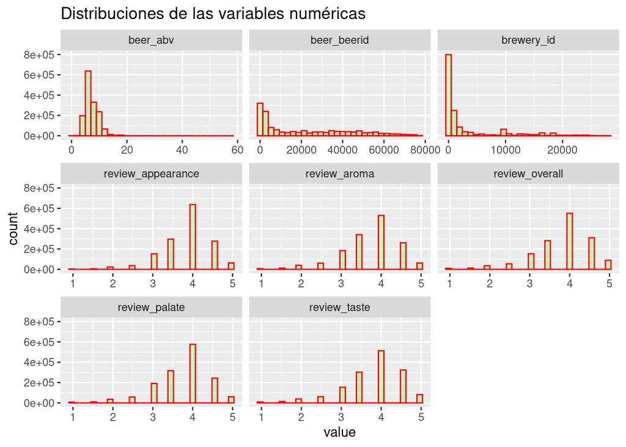

```r
library(purrr)
library(tidyr)
library(ggplot2)

rev %>%
  keep(is.numeric) %>%
  gather() %>%
  ggplot(aes(value)) +
    facet_wrap(~ key, scales = "free_x") +
    geom_histogram(col="red",
                   fill="green",
                   alpha = .2,) +
    ggtitle("Distribuciones de las variables numéricas")
```

**Tabla explicativa**

| Variables numéricas | Distribución | Interpretación |
| --- | --- | --- |
| `beer_abv` | Sesgado a la derecha | La mayoría de las cervezas tienen menos de un 20% de ABV |
| `beer_beerid` | Sesgado a la derecha | IDs más bajas tienen más reviews que IDs altas |
| `brewery_id` | Sesgado a la derecha | IDs más bajas tienen más reviews que IDs más altas |
| `review_appearance` | Sesgado a la izquierda | La mayoría de las cervezas tienen 4 de calificación |
| `review_aroma` | Normal | La mayoría de las cervezas tienen una calificación de 3 y 4 |
| `review_overall` | Sesgado a la izquierda | La mayoría de las cervezas tienen una calificación de 4 |
| `review_palate` | Normal | La mayoría de las cervezas tiene calificación 3 y 4 |
| `review_taste` | Normal | La mayoría de las cervezas está calificada entre 3.5 and 4.5 |

La mayoría de distribuciones no son normales, solo las variables “review_aroma”, “review_palate” y “review_taste” lo son. En la mayoría de modelos numéricos de aprendizaje automático necesitaremos que las variables sigan la distribución normal. Sin embargo, en el caso de las variables estudiadas del dataset vamos a observar una asimetría por la naturaleza sesgada a la que tienden las variables de tipo “calificativas”.

Llegado el caso y para mayor claridad podríamos realizar un **test de normalidad** para verificarlo y con la “función qqnorm” podríamos hacer un Q-Q plot para ver si una variable determinada tiene una distribución normal. Si se aleja de la linea roja, como es el caso, querrá decir que no lo es. Verificamos para la variable “beer_beerid” de la siguiente manera con la función especificada:

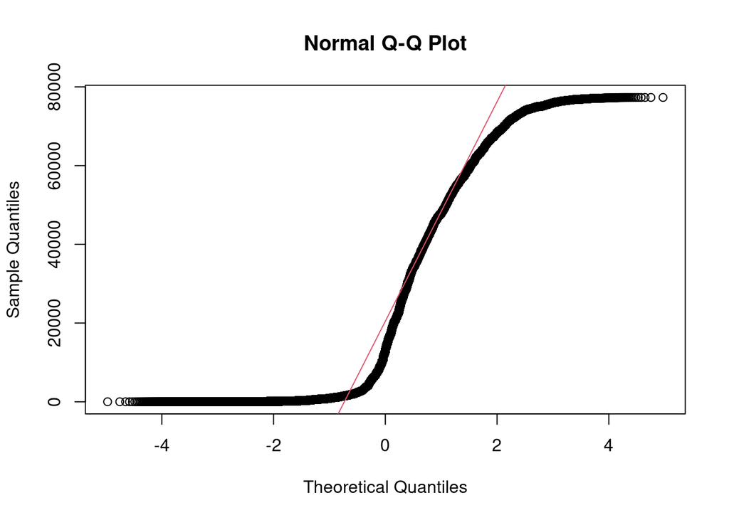

```r
qqnorm(rev$beer_beerid);qqline(rev$beer_beerid, col = 2)
```

El procedimiento que se puede seguir cuando tenemos una variable que no sigue una distribución normal es la de aplicar el logaritmo a la variable. Ésta es una de las transformaciones clásicas que puede funcionar. Lo verificamos de la siguiente manera para nuestro ejemplo con la variable “beer_beerid”:

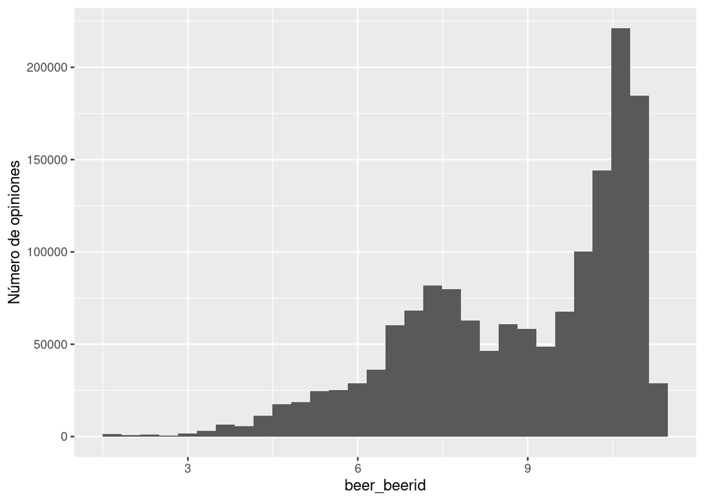

```r
rev$beer_beerid <- log(rev$beer_beerid)

ggplot(rev, aes(x = rev$beer_beerid)) +
  geom_histogram() +
  ylab("Número de opiniones") +
  xlab("beer_beerid")
```

Observamos como ahora cambia la distribución. Lo comprobamos con el Q-Q plot para confirmarlo.

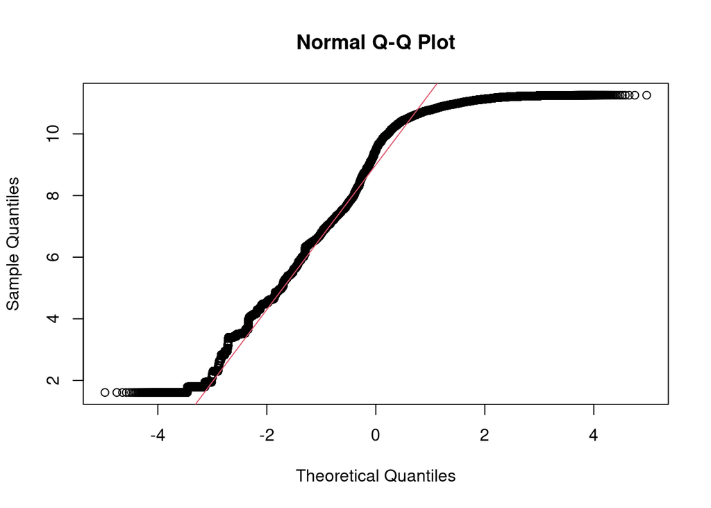

```r
qqnorm(rev$beer_beerid);qqline(rev$beer_beerid, col = 2)
```

El test de normalidad no es el esperado dada la naturaleza asimétrica de la variable estudiada (beer_beerid).

##### 3.2.5.1.2 Visión de la variable temporal:

Generamos un histograma para verificar la distribución de la variable temporal:

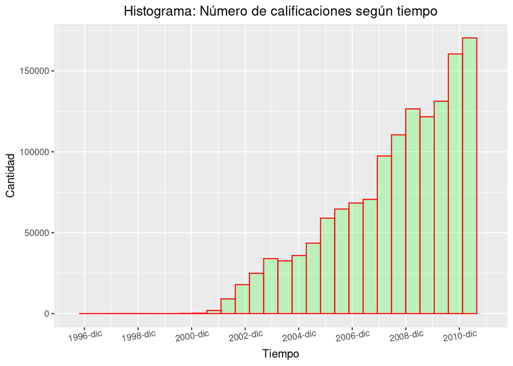

```r
library("ggplot2")
library("scales")
rev$review_time <- as.POSIXct(rev$review_time)

p <- ggplot(rev, aes(review_time, ..count..)) +
     geom_histogram(
       col="red",
       fill="green",
       alpha = .2,) +
     labs(title="Histograma: Número de calificaciones según tiempo", x="Tiempo", y="Cantidad") +
     theme_gray() +
     scale_x_datetime(breaks = date_breaks("2 year"),
                      labels = date_format("%Y-%b"),
                      limits = c(as.POSIXct("1996-08-22"),
                                as.POSIXct("2012-01-11")) ) +
     theme(axis.text.x = element_text(angle=10), plot.title = element_text(hjust = 0.5))
p
```

Observamos una distribución con sesgo a la izquierda. Dicha distribución sugiere una relación lineal entre el número de cervezas que se califican o puntúan y el periodo de tiempo. Podríamos utilizar dicha variable como una de las predictoras del modelo de minería que se escoja.

#### 3.2.5.2 Visión de las variables categóricas:

##### 3.2.5.2.1 Variable Cervecería (brewery_name):

En primer lugar, hay que tener en cuenta que existen más de 5k cervecerías en el dataset. Por lo tanto, tenemos que agruparlas según la cantidad de opiniones generadas y su importancia o “ranking” dentro del juego de datos.

En segundo lugar, examinamos los datos estadísticos descriptivos para esta variable:

```r
summary(rev$brewery_name)
```

```
##                         Boston Beer Company (Samuel Adams)
##                                                      38539
##                                       Dogfish Head Brewery
##                                                      33357
##                                          Stone Brewing Co.
##                                                      32507
##                                  Sierra Nevada Brewing Co.
##                                                      28240
##                                       Bell's Brewery, Inc.
##                                                      24613
##                                                 Rogue Ales
##                                                      22961
##                                   Founders Brewing Company
##                                                      19658
##                                    Victory Brewing Company
##                                                      19021
##                                  Lagunitas Brewing Company
##                                                      16661
##                                      Avery Brewing Company
##                                                      15843
##                              Southern Tier Brewing Company
##                                                      15594
##                                             Anheuser-Busch
##                                                      15229
##                               Great Divide Brewing Company
##                                                      14782
##                         Three Floyds Brewing Co. & Brewpub
##                                                      13866
##                                                   Unibroue
##                                                      13866
##                                      Goose Island Beer Co.
##                                                      13602
##                                           Brooklyn Brewery
##                                                      13582
##                                        New Belgium Brewing
##                                                      13205
##                                    Weyerbacher Brewing Co.
##                                                      11983
##                                         Flying Dog Brewery
##                                                      11629
```

[output cut: 145 more lines]

```
##                                                       3689
##                                       Breckenridge Brewery
##                                                       3681
##                                        Brouwerij Lindemans
##                                                       3632
##                                      Odell Brewing Company
##                                                       3611
##                                    Arcadia Brewing Company
##                                                       3577
##                                   Tyranena Brewing Company
##                                                       3401
##                                     Long Trail Brewing Co.
##                                                       3383
##                                                    (Other)
##                                                     635835
```

En cuarto lugar, determinamos el “ranking” de las 10 primeras empresas de cerveza con referencia a la cantidad de opiniones vertidas en el dataset:

```r
# Top ten cervecerías según cantidad de opiniones
top_10_brewery <- rev %>%
  count(brewery_name) %>%
  top_n(10) %>%
  arrange(desc(n, brewery_name)) %>%
  mutate(brewery_name = factor(brewery_name, levels = unique(brewery_name)))
top_10_brewery
```

```
##                          brewery_name     n
## 1  Boston Beer Company (Samuel Adams) 38539
## 2                Dogfish Head Brewery 33357
## 3                   Stone Brewing Co. 32507
## 4           Sierra Nevada Brewing Co. 28240
## 5                Bell's Brewery, Inc. 24613
## 6                          Rogue Ales 22961
## 7            Founders Brewing Company 19658
## 8             Victory Brewing Company 19021
## 9           Lagunitas Brewing Company 16661
## 10              Avery Brewing Company 15843
```

Finalmente, generamos el gráfico correspondiente:

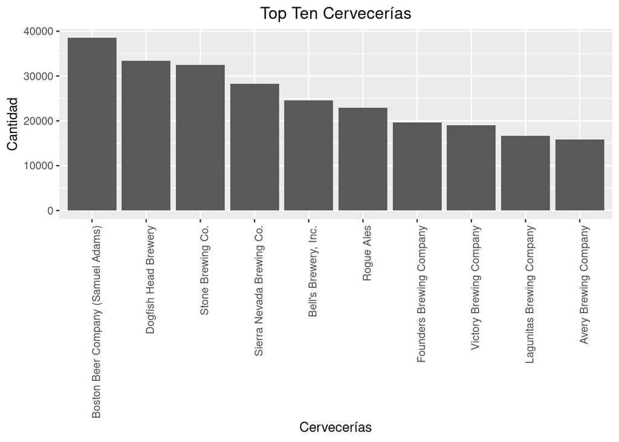

```r
rev %>%
  filter(brewery_name %in% top_10_brewery$brewery_name) %>%
  mutate(brewery_name = factor(brewery_name, levels = levels(top_10_brewery$brewery_name))) %>%
  ggplot(aes(x = brewery_name)) +
  labs(title="Top Ten Cervecerías", x="Cervecerías", y="Cantidad") +
  theme(axis.text.x=element_text(angle=90, hjust=1), plot.title = element_text(hjust = 0.5)) +
  geom_bar()
```

##### 3.2.5.2.2 Variable nombre de perfil (review_profilename):

En primer lugar, hay que tener en cuenta que existen más de 32k perfiles que han vertido su opinión en el dataset. Por lo tanto, tenemos que agruparlas según la cantidad de opiniones generadas y su importancia o “ranking” dentro del juego de datos.

```r
# Cantidad de nombres de perfil únicos del dataset
rev_profile_name <- length(unique(rev$review_profilename))
rev_profile_name
```

```
## [1] 32909
```

En segundo lugar, examinamos los datos estadísticos descriptivos para esta variable:

```r
summary(rev$review_profilename)
```

```
##   northyorksammy    BuckeyeNation      mikesgroove        Thorpe429
##             5177             4144             4130             3228
##    womencantsail     ChainGangGuy         Phyl21ca         brentk56
##             3115             3091             3083             3062
##      NeroFiddled           oberon           WesWes    feloniousmonk
##             3015             2834             2782             2732
##       Gueuzedude      BEERchitect   TheManiacalOne           jwc215
##             2690             2634             2490             2485
##       russpowell          Wasatch           zeff80          tempest
##             2420             2408             2368             2360
##          drabmuh         Mora2000          akorsak      Halcyondays
##             2358             2352             2344             2312
##            Viggo       WVbeergeek           Gavage           jdhilt
##             2310             2291             2272             2200
##           wl0307        weeare138            DrJay        Billolick
##             2143             2138             2082             2077
##           glid02         ppoitras           Gusler            Zorro
##             2069             2068             2064             2059
##          Knapp85       TMoney2591        emerge077            Jason
##             2054             2029             2023             2019
##        MasterSki           smcolw          Bighuge       rhoadsrage
##             2013             2007             2002             1979
##      Georgiabeer         biegaman         Kegatron   johnmichaelsen
##             1893             1889             1882             1881
##       beerthulhu      biboergosum        jrallen34            Derek
##             1863             1797             1781             1780
##            jpm30       RblWthACoz        tavernjef  TheLongBeachBum
##             1775             1757             1751             1750
##  barleywinefiend           RoyalT         corby112         gford217
##             1744             1735             1731             1725
##     TurdFurgison           mdfb79          DoubleJ         metter98
##             1713             1701             1684             1673
##           tpd975 Beerandraiderfan          mothman          plaid75
##             1669             1666             1653             1651
##           ccrida    francisweizen       scruffwhor         Dogbrick
##             1628             1622             1619             1615
##    woodychandler    LilBeerDoctor       Bitterbill        largadeer
##             1612             1599             1587             1579
##        GClarkage          Brad007   lacqueredmouse            cokes
##             1577             1570             1570             1569
##         merlin48        JohnGalt1          stcules        HopHead84
##             1560             1556             1555             1540
##         jlindros        AgentZero        Cyberkedi           hopdog
##             1537             1534             1534             1533
##        Slatetank             bark     BlackHaddock            Brent
##             1518             1517             1507             1499
##         avalon07              ZAP             dyan        Metalmonk
##             1491             1483             1470             1465
##         dirtylou         ffejherb        OWSLEY069          (Other)
##             1458             1456             1448          1295124
```

En tecer lugar, determinamos el “ranking” de los 10 primeros perfiles por cantidad de calificaciones vertidas en el dataset:

```r
# Top ten perfiles según cantidad de opiniones
top_10_profile <- rev %>%
  count(review_profilename) %>%
  top_n(10) %>%
  arrange(desc(n, review_profilename)) %>%
  mutate(review_profilename = factor(review_profilename, levels = unique(review_profilename)))
top_10_profile
```

```
##    review_profilename    n
## 1      northyorksammy 5177
## 2       BuckeyeNation 4144
## 3         mikesgroove 4130
## 4           Thorpe429 3228
## 5       womencantsail 3115
## 6        ChainGangGuy 3091
## 7            Phyl21ca 3083
## 8            brentk56 3062
## 9         NeroFiddled 3015
## 10             oberon 2834
```

Finalmente, generamos el gráfico correspondiente:

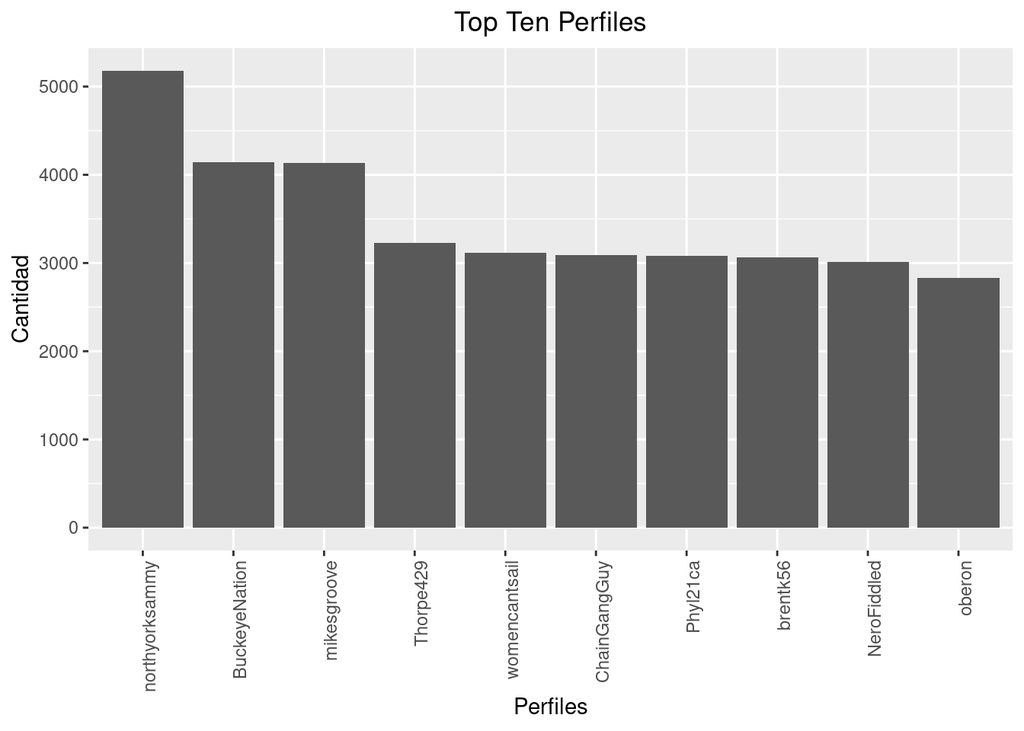

```r
rev %>%
  filter(review_profilename %in% top_10_profile$review_profilename) %>%
  mutate(review_profilename = factor(review_profilename, levels = levels(top_10_profile$review_profilename))) %>%
  ggplot(aes(x = review_profilename)) +
  labs(title="Top Ten Perfiles", x="Perfiles", y="Cantidad") +
  theme(axis.text.x=element_text(angle=90, hjust=1), plot.title = element_text(hjust = 0.5)) +
  geom_bar()
```

##### 3.2.5.2.3 Variable estilo de cerveza (beer_style):

```r
# Cantidad de nombres de perfil únicos del dataset
rev_beerstyle <- length(unique(rev$beer_style))
rev_beerstyle
```

```
## [1] 104
```

En segundo lugar, examinamos los datos estadísticos descriptivos para esta variable:

```r
summary(rev$beer_style)
```

```
##                        American IPA      American Double / Imperial IPA
##                              110430                               83648
##             American Pale Ale (APA)              Russian Imperial Stout
##                               56747                               52337
##    American Double / Imperial Stout                     American Porter
##                               49250                               46004
##            American Amber / Red Ale             Belgian Strong Dark Ale
##                               41207                               37136
##              Fruit / Vegetable Beer             Belgian Strong Pale Ale
##                               31782                               31095
##                 American Strong Ale              Saison / Farmhouse Ale
##                               31019                               30111
##                              Tripel              American Adjunct Lager
##                               29768                               28536
##                             Witbier                 American Barleywine
##                               28405                               26033
##                          Hefeweizen                  American Brown Ale
##                               25563                               23810
##             American Pale Wheat Ale                    English Pale Ale
##                               22625                               22426
##                      American Stout                Märzen / Oktoberfest
##                               22147                               21063
##                          Doppelbock                     German Pilsener
##                               20871                               20681
##                       Winter Warmer                              Dubbel
##                               19686                               19325
##                    Belgian Pale Ale                    Quadrupel (Quad)
##                               18785                               17839
##                   English Brown Ale                     Euro Pale Lager
##                               17559                               17333
##                   American Wild Ale                       Oatmeal Stout
##                               16720                               16584
##              Scotch Ale / Wee Heavy Extra Special / Strong Bitter (ESB)
##                               16507                               15867
##                         Pumpkin Ale        English India Pale Ale (IPA)
##                               14664                               14564
##                             Old Ale                  English Barleywine
##                               14391                               13331
##                         Light Lager                  Milk / Sweet Stout
##                               13058                               12415
```

[output cut: 45 more lines]

```
##                                2704                                2633
##          Keller Bier / Zwickel Bier                         Black & Tan
##                                2413                                2185
##                       Kristalweizen               English Dark Mild Ale
##                                2113                                2104
##                          Chile Beer                 Japanese Rice Lager
##                                2090                                1523
##             American Dark Wheat Ale     Bière de Champagne / Bière Brut
##                                1191                                1041
##                  Lambic - Unblended                    Low Alcohol Beer
##                                1034                                1017
##                             Braggot                               Sahti
##                                1010                                 991
##                                Gose                             (Other)
##                                 647                                2104
```

En tecer lugar, determinamos el “ranking” de los 10 estilos de cerveza por la cantidad de calificaciones existentes en el dataset:

```r
# Top ten estilos de cerveza según cantidad de opiniones
top_10_beerstyle <- rev %>%
  count(beer_style) %>%
  top_n(10) %>%
  arrange(desc(n, beer_style)) %>%
  mutate(beer_style = factor(beer_style, levels = unique(beer_style)))
top_10_beerstyle
```

```
##                          beer_style      n
## 1                      American IPA 110430
## 2    American Double / Imperial IPA  83648
## 3           American Pale Ale (APA)  56747
## 4            Russian Imperial Stout  52337
## 5  American Double / Imperial Stout  49250
## 6                   American Porter  46004
## 7          American Amber / Red Ale  41207
## 8           Belgian Strong Dark Ale  37136
## 9            Fruit / Vegetable Beer  31782
## 10          Belgian Strong Pale Ale  31095
```

Asimismo, generamos el gráfico correspondiente:

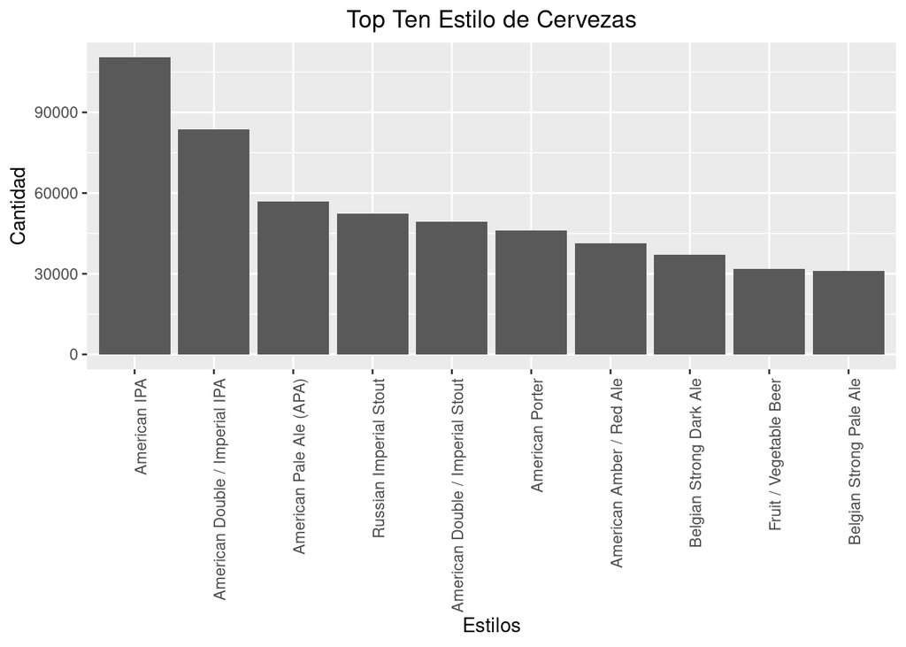

```r
rev %>%
  filter(beer_style %in% top_10_beerstyle$beer_style) %>%
  mutate(beer_style = factor(beer_style, levels = levels(top_10_beerstyle$beer_style))) %>%
  ggplot(aes(x = beer_style)) +
  labs(title="Top Ten Estilo de Cervezas", x="Estilos", y="Cantidad") +
  theme(axis.text.x=element_text(angle=90, hjust=1), plot.title = element_text(hjust = 0.5)) +
  geom_bar()
```

Por otro lado, debido a la importancia del estilo de la cerveza, podemos generar una variable que contenga de forma representativa algunos de los estilos de cerveza más genéricos y, de esa manera, facilitar la lectura e interpretación gráfica. Es así, que se procederá a la creación de una nueva variable “beer_type” de tipo factor a partir de la variable “beer_style”.

En ese sentido, cabe remarcar que existen tres grupos bien especificados según la fermentación y la levadura que se utilice en el proceso de fabricación [de la cerveza](https://www.insider.com/types-of-beer). Una cerveza puede ser “Ale”, “Lager” o “Hybrid”. Procedemos pues a realizar la nueva variable categórica derivada:

```r
# Cargamos las librerías necesarias
library(dplyr)
library(stringr)

# Hacemos un filtrado y creamos la nueva variable
rev <- rev %>%
  mutate(
  beer_type = case_when(
    str_detect(beer_style, "Ale|Pale Ale|APA") ~ "Ale",
    str_detect(beer_style, "Lager")            ~ "Lager",
    TRUE                                       ~ "Hybrid",
    )
  )

# Convertimos la variable en factor
rev$beer_type <- factor(rev$beer_type, ordered = FALSE)

# Verificamos los registros
head(rev)
```

```
##   brewery_id            brewery_name         review_time review_overall
## 1       1075 Caldera Brewing Company 2010-08-30 02:00:00              5
## 2       1075 Caldera Brewing Company 2011-10-16 02:00:00              5
## 3       1075 Caldera Brewing Company 2011-09-03 02:00:00              5
## 4       1075 Caldera Brewing Company 2011-05-20 02:00:00              5
## 5       1075 Caldera Brewing Company 2009-07-06 02:00:00              5
## 6       1075 Caldera Brewing Company 2009-03-01 01:00:00              5
##   review_aroma review_appearance review_profilename              beer_style
## 1          5.0               4.0       MadeInOregon    Herbed / Spiced Beer
## 2          5.0               3.5        optimator13               Rauchbier
## 3          4.5               4.0               Bung               Rauchbier
## 4          4.5               3.5             Deuane               Rauchbier
## 5          4.0               4.5    GratefulBeerGuy American Pale Ale (APA)
## 6          3.5               4.0            mtrentm American Pale Ale (APA)
##   review_palate review_taste           beer_name beer_abv beer_beerid beer_type
## 1           4.0            4 Caldera Ginger Beer      4.7    10.86205    Hybrid
## 2           3.5            5       Rauch Ür Bock      7.4    10.96899    Hybrid
## 3           4.0            5       Rauch Ür Bock      7.4    10.96899    Hybrid
## 4           4.0            5       Rauch Ür Bock      7.4    10.96899    Hybrid
## 5           4.5            4    Caldera Pale Ale      5.5    10.14306       Ale
## 6           4.0            5    Caldera Pale Ale      5.5    10.14306       Ale
```

```r
# Verificamos la columna recién creada:
summary(rev$beer_type)
```

```
##    Ale Hybrid  Lager
## 475575 909815 111199
```

Procedemos a graficar:

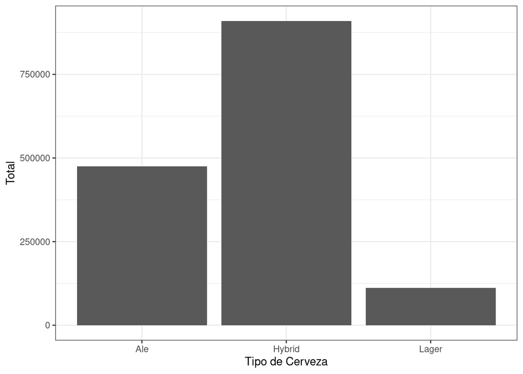

```r
# Visualizamos la distribución de los datos de la variable "beer_type"
ggplot((rev), aes(x=beer_type)) +
  geom_bar() +
  xlab("Tipo de Cerveza") +
  ylab("Total") +
  theme_bw()
```

##### 3.2.5.2.4 Variable nombre de la cerveza (beer_name):

En primer lugar, hay que tener en cuenta que existen más de 44k cervezas sobre los que se han hecho valoraciones. Por lo tanto, tenemos que agruparlas según la cantidad de valoraciones generadas y su importancia o “ranking” dentro del juego de datos.

```r
# Cantidad de nombres de cervezas únicos del dataset
rev_beername <- length(unique(rev$beer_name))
rev_beername
```

```
## [1] 44085
```

En segundo lugar, examinamos los datos estadísticos descriptivos para esta variable:

```r
summary(rev$beer_name)
```

```
##                                      90 Minute IPA
##                                               3207
##                Old Rasputin Russian Imperial Stout
##                                               3039
##                      Sierra Nevada Celebration Ale
##                                               2930
##                                Stone Ruination IPA
##                                               2645
##                               Arrogant Bastard Ale
##                                               2634
##                                    Two Hearted Ale
##                                               2632
##                         Stone IPA (India Pale Ale)
##                                               2527
##                             Sierra Nevada Pale Ale
##                                               2526
##                                    La Fin Du Monde
##                                               2480
##                                              Duvel
##                                               2449
##                           Founders Breakfast Stout
##                                               2444
##         Sierra Nevada Bigfoot Barleywine Style Ale
##                                               2444
##                                    Pliny The Elder
##                                               2432
##                                      60 Minute IPA
##                                               2430
##                     Brooklyn Black Chocolate Stout
##                                               2406
##                                   Storm King Stout
##                                               2393
##                          Samuel Adams Boston Lager
##                                               2348
##                                 Bell's Hopslam Ale
##                                               2347
##                       Stone Imperial Russian Stout
##                                               2286
##                                       HopDevil Ale
##                                               2240
```

[output cut: 145 more lines]

```
##                                               1408
##                            Pabst Blue Ribbon (PBR)
##                                               1408
##                                  Bell's Oberon Ale
##                                               1406
##                                   Delirium Tremens
##                                               1402
##                                           Pale Ale
##                                               1402
##                              Founders Red's Rye PA
##                                               1376
##                            Founders Centennial IPA
##                                               1367
##                                            (Other)
##                                            1314824
```

En tecer lugar, determinamos el “ranking” de las 10 cervezas con más cantidad de valoraciones:

```r
# Top ten cervezas según cantidad de opiniones
top_10_beername <- rev %>%
  count(beer_name) %>%
  top_n(10) %>%
  arrange(desc(n, beer_name)) %>%
  mutate(beer_name = factor(beer_name, levels = unique(beer_name)))
top_10_beername
```

```
##                              beer_name    n
## 1                        90 Minute IPA 3207
## 2  Old Rasputin Russian Imperial Stout 3039
## 3        Sierra Nevada Celebration Ale 2930
## 4                  Stone Ruination IPA 2645
## 5                 Arrogant Bastard Ale 2634
## 6                      Two Hearted Ale 2632
## 7           Stone IPA (India Pale Ale) 2527
## 8               Sierra Nevada Pale Ale 2526
## 9                      La Fin Du Monde 2480
## 10                               Duvel 2449
```

Finalmente, generamos el gráfico correspondiente:

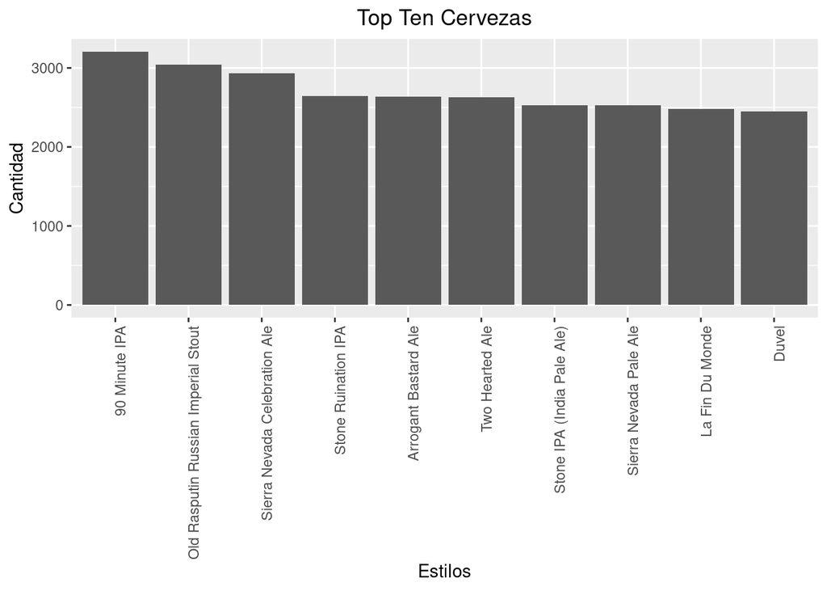

```r
rev %>%
  filter(beer_name %in% top_10_beername$beer_name) %>%
  mutate(beer_name = factor(beer_name, levels = levels(top_10_beername$beer_name))) %>%
  ggplot(aes(x = beer_name)) +
  labs(title="Top Ten Cervezas", x="Estilos", y="Cantidad") +
  theme(axis.text.x=element_text(angle=90, hjust=1), plot.title = element_text(hjust = 0.5)) +
  geom_bar()
```

#### 3.2.5.3 Análisis Bivariante:

Una vez descritas las variables categóricas en el apartado anterior, en este apartado, visualizaremos las relaciones de las distintas variables del dataset para sacar conclusiones más significativas.

**Calificación total en función de la graduación del alcohol**

Una de las variables más importantes que determinan el sabor de la cerveza es el **volumen de alcohol** en la misma. Estableceremos su relación con la calificación total.

Procedemos a generar el gráfico con la técnica “jitter” al tratarse de una variable discreta y otra continua:

```r
# Librerías
library(tidyverse)
library(dplyr)
library(GGally)
```

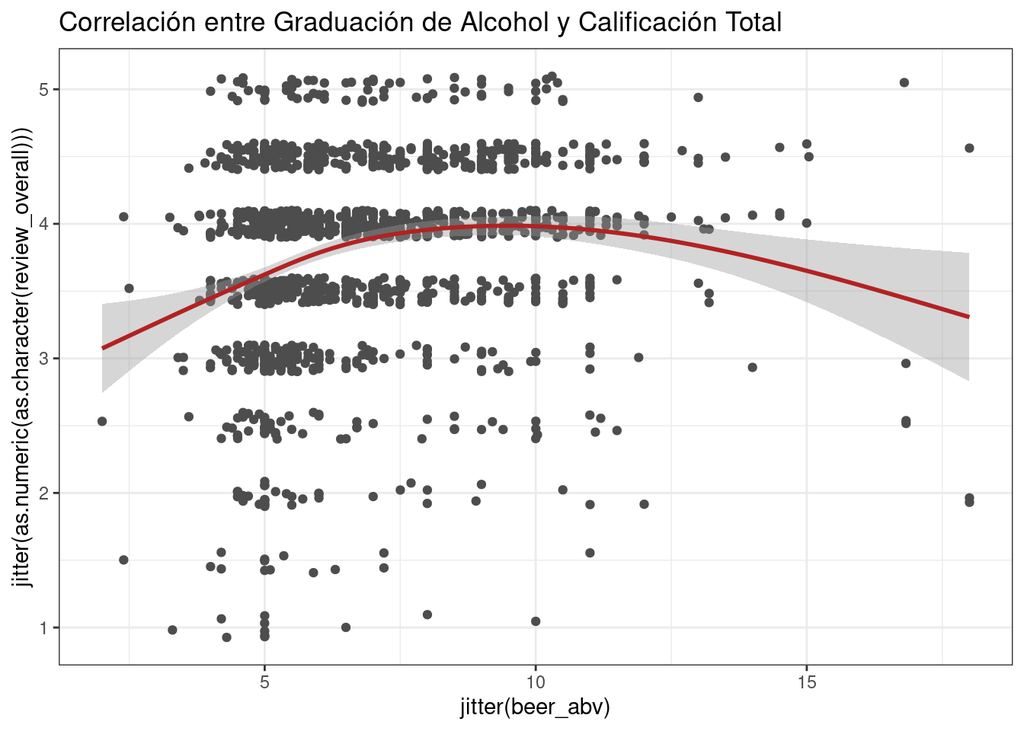

```r
# Subset
rev_abv_rev_ov <- rev %>%
  subset(select = c("review_overall", "beer_abv"))

# Sample
s_rev_abv_rev_ov <- sample_frac(rev_abv_rev_ov, 0.001)

# Plot
ggplot(data = s_rev_abv_rev_ov, aes(x = jitter(beer_abv), y = jitter(as.numeric(as.character(review_overall))))) +
  geom_point(color = "gray30") +
  geom_smooth(color = "firebrick") +
  theme_bw() +
  ggtitle("Correlación entre Graduación de Alcohol y Calificación Total")
```

**Calificación total en función de la Estilo de cerveza**

Otra variable importante es el **estilo de la cerveza**, el cual determinará una calificación alta o baja dependiendo del gusto del consumidor. Graficaremos dicha relación con un “boxplot”, de la siguiente manera:

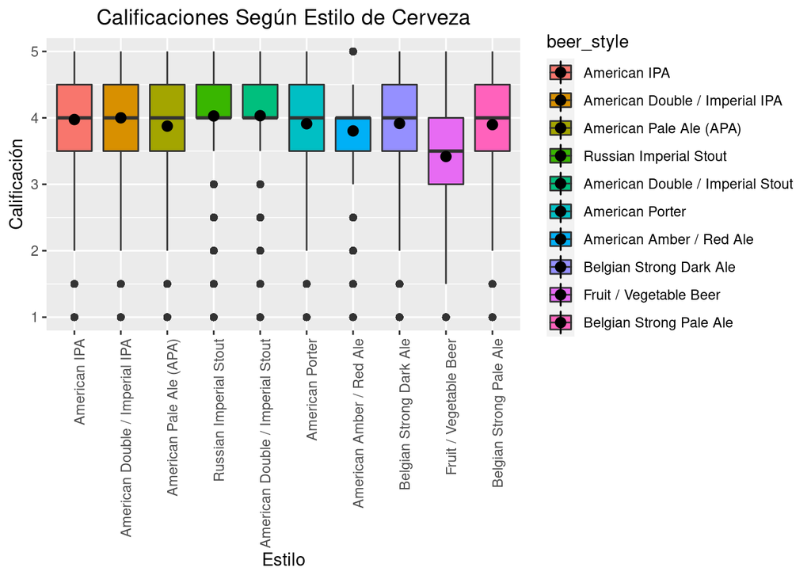

```r
# Top ten cervezas según cantidad de opiniones
top_10_beerstyle <- rev %>%
  count(beer_style) %>%
  top_n(10) %>%
  arrange(desc(n, beer_style)) %>%
  mutate(beer_style = factor(beer_style, levels = unique(beer_style)))

rev %>%
  filter(beer_style %in% top_10_beerstyle$beer_style) %>%
  mutate(beer_style = factor(beer_style, levels = levels(top_10_beerstyle$beer_style))) %>%
  ggplot(rev, mapping = aes(x=beer_style, y=review_overall, fill=beer_style)) +
  labs(title="Calificaciones Según Estilo de Cerveza", x="Estilo", y="Calificación") +
  theme(axis.text.x=element_text(angle=90, hjust=1), plot.title = element_text(hjust = 0.5)) +
  geom_boxplot() +
  stat_summary(fun=mean)
```

Según el gráfico “boxplot” podemos intuir que los estilos tipo “Ale” tienen una distribución más o menos simétrica y la mediana se ubica en el 4 de calificación.

**Calificación total en función del tipo de Cerveza**

De otro lado, representaremos la relación entre la variable “beer_type” y la variable “review_overall” mediante un histograma agrupado por niveles de calificación.

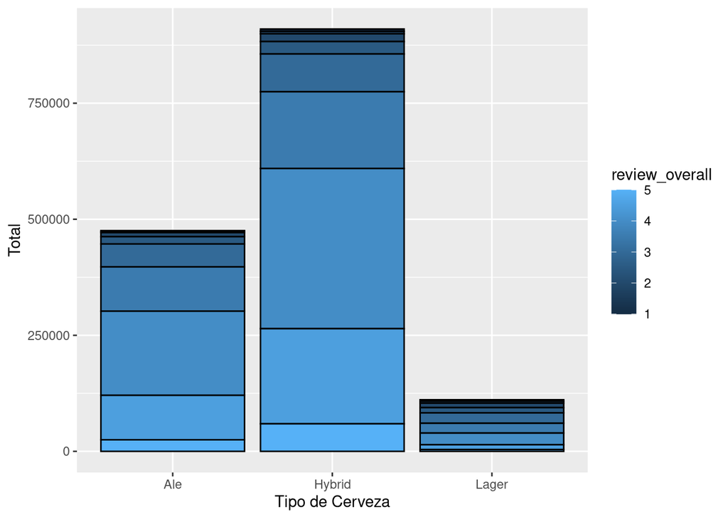

```r
# Visualizamos la relación
ggplot(rev) +
  aes(x=beer_type, group=review_overall, fill=review_overall) +
  geom_bar(color='black', stat="count") +
  xlab("Tipo de Cerveza") +
  ylab("Total") +
  theme_gray()
```

Obtenemos una matriz de porcentajes de frecuencia:

```r
# Tabla de frecuencias
t<-table(rev[,]$beer_type, rev[,]$review_overall)
for (i in 1:dim(t)[1]){
    t[i,]<-t[i,]/sum(t[i,])*100
}
t
```

```
##
##                   1        1.5          2        2.5          3        3.5
##   Ale     0.4165484  0.4937181  1.8545971  3.2920149 10.3830100 20.0685486
##   Hybrid  0.5498920  0.5762710  1.8424625  2.9382897  8.9522595 18.1711667
##   Lager   2.7940899  3.8174804  8.6493584 10.2078256 20.0892094 19.0019694
##
##                   4        4.5          5
##   Ale    38.0968302 20.1476108  5.2471219
##   Hybrid 37.9202365 22.5234800  6.5259421
##   Lager  22.6027212  9.2150109  3.6223347
```

Vemos, por ejemplo, que la probabilidad de una calificación de 4 puntos es de 38.09% si la cerveza es de tipo “Ale”.

La variable “beer_type” presenta diferencias marcadas en cuanto a la calificación final según el tipo de cerveza.

**Calificación total en función del tiempo**

En otro orden de ideas, visualizamos el gráfico de dispersión de las dos variables para encontrar alguna relación lineal. Procedemos de la siguiente manera:

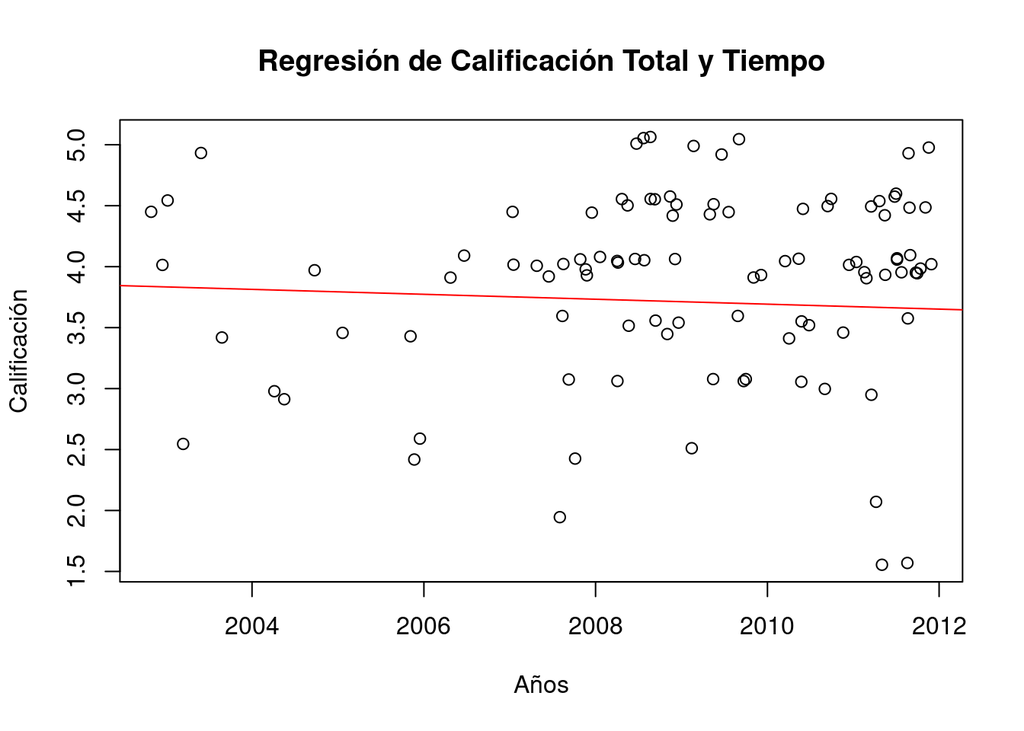

```r
# Gráfico de dispersión
plot(jitter(sample(rev$review_overall, 100))~sample(rev$review_time, 100),
     main='Regresión de Calificación Total y Tiempo',
     xlab='Años', ylab='Calificación')

# plot la línea de regresión
abline(lm(jitter(sample(rev$review_overall, 100))~sample(rev$review_time, 100), data=rev), col='red')
```

**Pairs plot**

Finalmente, podemos crear una muestra aleatoria para graficar un pairplot de las variables numéricas de la siguiente manera:

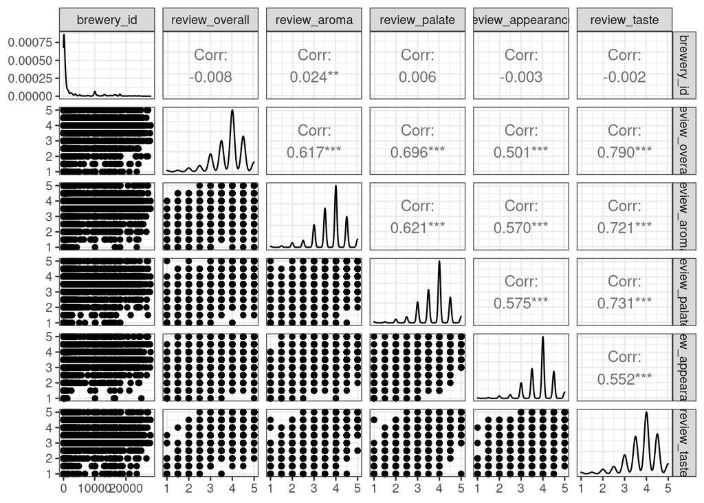

```r
# Librerías
library(tidyverse)
library(dplyr)
library(GGally)

# Subset
rev_sub <- rev %>%
  subset(select = c("brewery_id", "review_overall", "review_aroma", "review_palate", "review_appearance", "review_taste"))

# Sample

rev_sample <- sample_frac(rev_sub, 0.01)

# Plot
ggpairs(rev_sample) + theme_bw()
```